# Resolución Actividad 3 máster Bioinformática UNIR (2026)

Equipo R

2026-06-14

**Métodos preliminares**

**Habilitación CRAN**

```r
options(repos = c(CRAN = "https://cloud.r-project.org"))
```

# 1 IDENTIFICACIÓN DE EJES DE VARIABILIDAD GÉNICA Y SU ASOCIACIÓN CON EL ESTADO PONDERAL EN INDIVIDUOS SIMPSON

## 1.1 INTRODUCCIÓN

- **La evaluación de la normalidad** de las variables de expresión génica
- **La reducción de dimensionalidad mediante análisis de componentes principales (PCA)**
- **La visualización y agrupación de variables e individuos (clustering)**
- **La generación de representaciones gráficas**, incluyendo **heatmaps** de correlación y otras visualizaciones exploratorias
- **El análisis descriptivo**, mediante **tablas de los datos crudos y de las variables transformadas**
- La construcción de un **modelo predictivo mediante regresión logística**

  A lo largo de cada apartado, se detallarán los procedimientos empleados y se interpretarán los resultados obtenidos, valorando su significado estadístico y su posible relevancia en el contexto biológico y clínico del problema estudiado.

## 1.2 ESTABLECIMIENTO DEL ESPACIO DE TRABAJO

Declaramos el entorno de trabajo en la carpeta concreta del equipo del creador e instalamos los paquetes y librerías que van a ser necesarios para las operaciones.

```r
setwd("C:/Users/alber/Desktop/UNIR 26 -27/Primer cuatrimestre/Estadística y R para las Ciencias de la Salud/Actividades/Actividad grupal/Trabajos")

## Compruebo que la ruta sea correcta.

getwd()
```

```
## [1] "C:/Users/alber/Desktop/UNIR 26 -27/Primer cuatrimestre/Estadística y R para las Ciencias de la Salud/Actividades/Actividad grupal/Trabajos"
```

```r
## Reviso los archivos disponibles en la carpeta.

list.files()
```

```
##  [1] "Base_de_datos_Los_Simpson_completa.csv"
##  [2] "Base_de_datos_Los_Simpson_IMC_corregido.csv"
##  [3] "Bloques código R"
##  [4] "Póster"
##  [5] "Resolución-Actividad-3-máster-Bioinformática-UNIR--2026-.html"
##  [6] "Resolución-Actividad-3-máster-Bioinformática-UNIR--2026-.Rmd"
##  [7] "Resolución Actividad 3 máster Bioinformática UNIR (2026).Rmd"
##  [8] "Tabla Regresion.csv"
##  [9] "tabla_pca_cargas.csv"
## [10] "tabla_pca_cargas.png"
## [11] "tabla_pca_componentes_R2.csv"
## [12] "tabla_pca_componentes_R2.png"
## [13] "Tablas"
```

## 1.3 LIMPIEZA DEL ENTORNO, REPRODUCIBILIDAD Y PAQUETES

```r
## Limpio el entorno para evitar que objetos creados anteriormente
## interfieran con los resultados de esta actividad.

rm(list = ls())

## Fijo una semilla para que los procedimientos aleatorios,
## como el clustering, puedan reproducirse.

set.seed(2026)

## Evito que R utilice notación científica cuando no sea necesaria.

options(scipen = 999)

## Defino los paquetes que utilizaré durante el análisis.

paquetes <- c(
  "dplyr",
  "tidyr",
  "ggplot2",
  "janitor",
  "factoextra",
  "FactoMineR",
  "pheatmap",
  "gtsummary",
  "flextable",
  "officer",
  "broom",
  "car",
  "pROC",
  "readr",
  "ggrepel"
)

## Compruebo qué paquetes todavía no están instalados.

paquetes_nuevos <- paquetes[
  !paquetes %in% rownames(installed.packages())
]

## Instalo solamente los paquetes que falten.

if (length(paquetes_nuevos) > 0) {
  install.packages(paquetes_nuevos, dependencies = TRUE)
}

## Cargo las librerías necesarias.

library(dplyr)
library(tidyr)
library(ggplot2)
library(janitor)
library(factoextra)
library(FactoMineR)
library(pheatmap)
library(gtsummary)
library(flextable)
library(officer)
library(broom)
library(car)
library(pROC)
library(readr)
library(ggrepel)
```

## 1.4 CARGA Y EXPLORACIÓN INICIAL DE LA BASE DE DATOS

Tomamos los datos desde el dataset aportado, sito en el espacio de trabajo declarado

```r
## Cargo la base de datos en formato CSV.

simpson_df <- read_csv("Base_de_datos_Los_Simpson_completa.csv")
```

```
## ──────────────────────────────────────────────────────── Delimiter: "," chr
## (16): nombre, sexo, estado_civil, nivel_educativo, ocupacion, lugar_resi... dbl
## (81): ...1, orden, edad_anios, altura, peso_kg, imc_kg_m2, ccintura_cm, ...
```

```r
# Exploración inicial para comprobar estructura
summary(simpson_df)
```

```
##       ...1          orden            nombre     edad_anios           sexo
##  Min.   : 1.0   Min.   : 1.0   Length   :59   Min.   : 1.00   Length   :59
##  1st Qu.:15.5   1st Qu.:15.5   N.unique :59   1st Qu.:35.00   N.unique : 2
##  Median :30.0   Median :30.0   N.blank  : 0   Median :40.00   N.blank  : 0
##  Mean   :30.0   Mean   :30.0   Min.nchar: 3   Mean   :39.81   Min.nchar: 8
##  3rd Qu.:44.5   3rd Qu.:44.5   Max.nchar:24   3rd Qu.:45.00   Max.nchar: 9
##  Max.   :59.0   Max.   :59.0                  Max.   :90.00
##
##      altura         peso_kg      imc_kg_m2      ccintura_cm
##  Min.   : 70.0   Min.   :  9   Min.   :16.65   Min.   : 45.00
##  1st Qu.:163.5   1st Qu.: 60   1st Qu.:22.04   1st Qu.: 73.50
##  Median :175.0   Median : 75   Median :24.69   Median : 85.00
##  Mean   :167.6   Mean   : 72   Mean   :24.95   Mean   : 82.54
##  3rd Qu.:180.0   3rd Qu.: 85   3rd Qu.:27.09   3rd Qu.: 90.00
##  Max.   :200.0   Max.   :130   Max.   :42.45   Max.   :120.00
##
##    ccadera_cm     grasa_corporal_pct longitud_brazos_cm longitud_piernas_cm
##  Min.   : 50.00   Min.   :12.00      Min.   :30.00      Min.   : 40.00
##  1st Qu.: 85.00   1st Qu.:19.00      1st Qu.:60.00      1st Qu.: 80.00
##  Median : 95.00   Median :22.00      Median :65.00      Median : 82.00
##  Mean   : 91.95   Mean   :22.31      Mean   :65.29      Mean   : 82.73
##  3rd Qu.:100.00   3rd Qu.:25.00      3rd Qu.:70.00      3rd Qu.: 90.00
##  Max.   :130.00   Max.   :40.00      Max.   :80.00      Max.   :110.00
##
##  diametro_biacromial_cm diametro_bicrestal_cm    estado_civil  nivel_educativo
##  Min.   :25.00          Min.   :22.00         Length   :59    Length   :59
##  1st Qu.:34.50          1st Qu.:29.00         N.unique : 2    N.unique : 3
##  Median :36.00          Median :32.00         N.blank  : 0    N.blank  : 0
##  Mean   :36.53          Mean   :31.75         Min.nchar: 6    Min.nchar:13
##  3rd Qu.:39.50          3rd Qu.:35.00         Max.nchar: 7    Max.nchar:22
##  Max.   :52.00          Max.   :45.00
##
##      ocupacion  ingreso_anual_usd  lugar_residencia     etnicidad
##  Length   :59   Min.   : 10000    Length   :59      Length   :59
##  N.unique : 6   1st Qu.: 25350    N.unique : 2      N.unique : 5
##  N.blank  : 0   Median : 31800    N.blank  : 0      N.blank  : 0
##  Min.nchar: 4   Mean   : 40033    Min.nchar: 7      Min.nchar: 5
##  Max.nchar:11   3rd Qu.: 50000    Max.nchar:11      Max.nchar:13
##                 Max.   :100000
##                 NAs    :5
```

[output cut: 137 more lines]

```
##  Min.   :-1.0799   Min.   :-2.16182   Min.   :-1.2758   Min.   :-1.0914
##  1st Qu.:-0.9617   1st Qu.:-0.53153   1st Qu.:-0.9255   1st Qu.:-0.1725
##  Median :-0.4184   Median : 0.60506   Median :-0.2107   Median : 1.0334
##  Mean   :-0.2398   Mean   :-0.06651   Mean   :-0.4193   Mean   : 0.4774
##  3rd Qu.: 0.1069   3rd Qu.: 0.75188   3rd Qu.:-0.1195   3rd Qu.: 1.2093
##  Max.   : 1.9491   Max.   : 0.76627   Max.   : 1.5484   Max.   : 1.2174
##
##      SPARC              TMEM18               UBR2             UHMK1
##  Min.   :-1.33303   Min.   :-1.942640   Min.   :-0.7866   Min.   :-1.9536
##  1st Qu.:-0.36990   1st Qu.:-0.658953   1st Qu.:-0.7207   1st Qu.:-0.7481
##  Median :-0.04117   Median : 0.632810   Median : 0.6804   Median :-0.6308
##  Mean   :-0.02879   Mean   :-0.004475   Mean   : 0.2331   Mean   :-0.3678
##  3rd Qu.: 0.81727   3rd Qu.: 0.832696   3rd Qu.: 1.3330   3rd Qu.: 0.7134
##  Max.   : 1.28911   Max.   : 1.004759   Max.   : 1.4964   Max.   : 0.7134
##
```

```r
## Reviso las dimensiones de la base de datos.

dim(simpson_df)
```

```
## [1] 59 97
```

```r
## Reviso la estructura general de las variables.

str(simpson_df)
```

```
## spc_tbl_ [59 × 97] (S3: spec_tbl_df/tbl_df/tbl/data.frame)
##  $ ...1                   : num [1:59] 1 2 3 4 5 6 7 8 9 10 ...
##  $ orden                  : num [1:59] 10 2 17 7 8 1 18 54 13 32 ...
##  $ nombre                 : chr [1:59] "Barney Gumble" "Homer Simpson" "Apu Nahasapeemapetilon" "Patty Bouvier" ...
##  $ edad_anios             : num [1:59] 39 40 35 40 40 80 45 80 9 50 ...
##  $ sexo                   : chr [1:59] "Masculino" "Masculino" "Masculino" "Femenino" ...
##  $ altura                 : num [1:59] 175 175 170 170 170 170 180 140 130 175 ...
##  $ peso_kg                : num [1:59] 130 120 110 95 93 90 100 58 50 90 ...
##  $ imc_kg_m2              : num [1:59] 42.4 39.2 38.1 32.9 32.2 ...
##  $ ccintura_cm            : num [1:59] 110 120 95 75 76 95 110 70 65 95 ...
##  $ ccadera_cm             : num [1:59] 110 130 100 95 95 105 115 85 75 100 ...
##  $ grasa_corporal_pct     : num [1:59] 40 40 25 25 27 30 30 22 20 30 ...
##  $ longitud_brazos_cm     : num [1:59] 70 65 65 72 72 65 70 45 70 74 ...
##  $ longitud_piernas_cm    : num [1:59] 90 90 80 80 80 80 85 60 80 88 ...
##  $ diametro_biacromial_cm : num [1:59] 35 40 37 38 38 38 39 30 30 38 ...
##  $ diametro_bicrestal_cm  : num [1:59] 30 35 31 33 33 32 33 25 28 30 ...
##  $ estado_civil           : chr [1:59] "Soltero" "Casado" "Casado" "Soltero" ...
##  $ nivel_educativo        : chr [1:59] "Sin educacion" "estudios obligatorios" "estudios obligatorios" "graduado universitario" ...
##  $ ocupacion              : chr [1:59] "Paro" "trabajador" "trabajador" "trabajador" ...
##  $ ingreso_anual_usd      : num [1:59] 20000 40000 40000 30000 30000 25000 50000 21600 30000 90000 ...
##  $ lugar_residencia       : chr [1:59] "Springfield" "Springfield" "Springfield" "Springfield" ...
##  $ etnicidad              : chr [1:59] "Caucásico" "Caucásico" "Indio" "Caucásico" ...
##  $ situacion_vivienda     : chr [1:59] "Vive en un bar" "Propietario de vivienda en mal estado" "Propietario de tienda" "Apartamento" ...
##  $ composicion_familiar   : chr [1:59] "Soltero" "Casado" "Casado" "Soltero" ...
##  $ enfermedades           : chr [1:59] "Alcoholismo" "Enfermedad cardiovascular" "Diabetes tipo 2" "Diabetes tipo 2" ...
##  $ medicamento            : chr [1:59] "Alcoholismo" "Anticoagulantes" "Antidiabéticos" "Antidiabéticos" ...
##  $ frutas_g_d             : num [1:59] 50 100 150 150 150 150 150 40 150 30 ...
##  $ verduras_g_d           : num [1:59] 30 100 100 200 200 100 100 50 150 60 ...
##  $ cereales_g_d           : num [1:59] 350 300 300 150 150 300 200 150 200 160 ...
##  $ legumbres_g_d          : num [1:59] 20 10 10 40 40 10 20 30 20 40 ...
##  $ frutos_secos_g_d       : num [1:59] 5 5 15 20 20 15 10 10 5 25 ...
##  $ lacteos_g_d            : num [1:59] 200 300 150 200 200 200 200 150 250 250 ...
##  $ carnes_g_d             : num [1:59] 300 250 250 200 200 250 150 150 150 150 ...
##  $ pescados_g_d           : num [1:59] 10 30 30 40 40 30 20 80 20 60 ...
##  $ huevos_g_d             : num [1:59] 0 30 5 17 17 20 10 60 5 10 ...
##  $ aceites_g_d            : num [1:59] 20 50 40 15 15 40 30 25 10 20 ...
##  $ bolleria_industrial_g_d: num [1:59] 200 150 100 15 15 200 80 100 40 20 ...
##  $ af_moderada_h_semana   : num [1:59] 0 1 2 3 3 1 1 2 2 1 ...
##  $ af_intensa_h_semana    : num [1:59] 0 0 0 1 1 0 1 0 1 1 ...
##  $ tabaco                 : chr [1:59] "Fumador" "No fumador" "Fumador" "No fumador" ...
```

[output cut: 144 more lines]

```
##   ..   NTRK2 = col_double(),
##   ..   PCSK1 = col_double(),
##   ..   PDE3B = col_double(),
##   ..   PHIP = col_double(),
##   ..   POMC = col_double(),
##   ..   PPARG = col_double(),
##   ..   ROBO1 = col_double(),
##   ..   SH2B1 = col_double(),
##   ..   SIM1 = col_double(),
##   ..   SPARC = col_double(),
##   ..   TMEM18 = col_double(),
##   ..   UBR2 = col_double(),
##   ..   UHMK1 = col_double()
##   .. )
##  - attr(*, "problems")=<pointer: 0x00000277645face0>
```

```r
## Reviso los nombres de todas las variables.

names(simpson_df)
```

```
##  [1] "...1"                    "orden"
##  [3] "nombre"                  "edad_anios"
##  [5] "sexo"                    "altura"
##  [7] "peso_kg"                 "imc_kg_m2"
##  [9] "ccintura_cm"             "ccadera_cm"
## [11] "grasa_corporal_pct"      "longitud_brazos_cm"
## [13] "longitud_piernas_cm"     "diametro_biacromial_cm"
## [15] "diametro_bicrestal_cm"   "estado_civil"
## [17] "nivel_educativo"         "ocupacion"
## [19] "ingreso_anual_usd"       "lugar_residencia"
## [21] "etnicidad"               "situacion_vivienda"
## [23] "composicion_familiar"    "enfermedades"
## [25] "medicamento"             "frutas_g_d"
## [27] "verduras_g_d"            "cereales_g_d"
## [29] "legumbres_g_d"           "frutos_secos_g_d"
```

[output cut: 34 more lines]

```r
## Reviso las primeras filas del dataset.

head(simpson_df)
```

```
## # A tibble: 6 × 97
##    ...1 orden nombre       edad_anios sexo  altura peso_kg imc_kg_m2 ccintura_cm
##   <dbl> <dbl> <chr>             <dbl> <chr>  <dbl>   <dbl>     <dbl>       <dbl>
## 1     1    10 Barney Gumb…         39 Masc…    175     130      42.4         110
## 2     2     2 Homer Simps…         40 Masc…    175     120      39.2         120
## 3     3    17 Apu Nahasap…         35 Masc…    170     110      38.1          95
## 4     4     7 Patty Bouvi…         40 Feme…    170      95      32.9          75
## 5     5     8 Selma Bouvi…         40 Feme…    170      93      32.2          76
## 6     6     1 Abraham Sim…         80 Masc…    170      90      31.1          95
## # ℹ 88 more variables: ccadera_cm <dbl>, grasa_corporal_pct <dbl>,
## #   longitud_brazos_cm <dbl>, longitud_piernas_cm <dbl>,
## #   diametro_biacromial_cm <dbl>, diametro_bicrestal_cm <dbl>,
## #   estado_civil <chr>, nivel_educativo <chr>, ocupacion <chr>,
## #   ingreso_anual_usd <dbl>, lugar_residencia <chr>, etnicidad <chr>,
## #   situacion_vivienda <chr>, composicion_familiar <chr>, enfermedades <chr>,
## #   medicamento <chr>, frutas_g_d <dbl>, verduras_g_d <dbl>, …
```

```r
## Obtengo un resumen general de las variables.

summary(simpson_df)
```

```
##       ...1          orden            nombre     edad_anios           sexo
##  Min.   : 1.0   Min.   : 1.0   Length   :59   Min.   : 1.00   Length   :59
##  1st Qu.:15.5   1st Qu.:15.5   N.unique :59   1st Qu.:35.00   N.unique : 2
##  Median :30.0   Median :30.0   N.blank  : 0   Median :40.00   N.blank  : 0
##  Mean   :30.0   Mean   :30.0   Min.nchar: 3   Mean   :39.81   Min.nchar: 8
##  3rd Qu.:44.5   3rd Qu.:44.5   Max.nchar:24   3rd Qu.:45.00   Max.nchar: 9
##  Max.   :59.0   Max.   :59.0                  Max.   :90.00
##
##      altura         peso_kg      imc_kg_m2      ccintura_cm
##  Min.   : 70.0   Min.   :  9   Min.   :16.65   Min.   : 45.00
##  1st Qu.:163.5   1st Qu.: 60   1st Qu.:22.04   1st Qu.: 73.50
##  Median :175.0   Median : 75   Median :24.69   Median : 85.00
##  Mean   :167.6   Mean   : 72   Mean   :24.95   Mean   : 82.54
##  3rd Qu.:180.0   3rd Qu.: 85   3rd Qu.:27.09   3rd Qu.: 90.00
##  Max.   :200.0   Max.   :130   Max.   :42.45   Max.   :120.00
##
##    ccadera_cm     grasa_corporal_pct longitud_brazos_cm longitud_piernas_cm
##  Min.   : 50.00   Min.   :12.00      Min.   :30.00      Min.   : 40.00
##  1st Qu.: 85.00   1st Qu.:19.00      1st Qu.:60.00      1st Qu.: 80.00
##  Median : 95.00   Median :22.00      Median :65.00      Median : 82.00
##  Mean   : 91.95   Mean   :22.31      Mean   :65.29      Mean   : 82.73
##  3rd Qu.:100.00   3rd Qu.:25.00      3rd Qu.:70.00      3rd Qu.: 90.00
##  Max.   :130.00   Max.   :40.00      Max.   :80.00      Max.   :110.00
##
##  diametro_biacromial_cm diametro_bicrestal_cm    estado_civil  nivel_educativo
##  Min.   :25.00          Min.   :22.00         Length   :59    Length   :59
##  1st Qu.:34.50          1st Qu.:29.00         N.unique : 2    N.unique : 3
##  Median :36.00          Median :32.00         N.blank  : 0    N.blank  : 0
##  Mean   :36.53          Mean   :31.75         Min.nchar: 6    Min.nchar:13
##  3rd Qu.:39.50          3rd Qu.:35.00         Max.nchar: 7    Max.nchar:22
##  Max.   :52.00          Max.   :45.00
##
##      ocupacion  ingreso_anual_usd  lugar_residencia     etnicidad
##  Length   :59   Min.   : 10000    Length   :59      Length   :59
##  N.unique : 6   1st Qu.: 25350    N.unique : 2      N.unique : 5
##  N.blank  : 0   Median : 31800    N.blank  : 0      N.blank  : 0
##  Min.nchar: 4   Mean   : 40033    Min.nchar: 7      Min.nchar: 5
##  Max.nchar:11   3rd Qu.: 50000    Max.nchar:11      Max.nchar:13
##                 Max.   :100000
##                 NAs    :5
```

[output cut: 137 more lines]

```
##  Min.   :-1.0799   Min.   :-2.16182   Min.   :-1.2758   Min.   :-1.0914
##  1st Qu.:-0.9617   1st Qu.:-0.53153   1st Qu.:-0.9255   1st Qu.:-0.1725
##  Median :-0.4184   Median : 0.60506   Median :-0.2107   Median : 1.0334
##  Mean   :-0.2398   Mean   :-0.06651   Mean   :-0.4193   Mean   : 0.4774
##  3rd Qu.: 0.1069   3rd Qu.: 0.75188   3rd Qu.:-0.1195   3rd Qu.: 1.2093
##  Max.   : 1.9491   Max.   : 0.76627   Max.   : 1.5484   Max.   : 1.2174
##
##      SPARC              TMEM18               UBR2             UHMK1
##  Min.   :-1.33303   Min.   :-1.942640   Min.   :-0.7866   Min.   :-1.9536
##  1st Qu.:-0.36990   1st Qu.:-0.658953   1st Qu.:-0.7207   1st Qu.:-0.7481
##  Median :-0.04117   Median : 0.632810   Median : 0.6804   Median :-0.6308
##  Mean   :-0.02879   Mean   :-0.004475   Mean   : 0.2331   Mean   :-0.3678
##  3rd Qu.: 0.81727   3rd Qu.: 0.832696   3rd Qu.: 1.3330   3rd Qu.: 0.7134
##  Max.   : 1.28911   Max.   : 1.004759   Max.   : 1.4964   Max.   : 0.7134
##
```

## 1.5 Resultados de la exploracion inicial.

La base de datos contiene 59 pacientes y 97 variables, entre ellas 37 genes desde ADCY3 hasta UHMK1. Los genes están en formato numérico y no presentan valores perdidos, por lo que pueden usarse directamente en el PCA. Solo se detectaron 5 NA en ingreso_anual_usd, que no afectan al análisis génico. Como los genes tienen escalas diferentes, es correcto centrar y escalar antes del PCA.

## 1.6 CONTROL DE CALIDAD INICIAL

```r
## Compruebo el número total de valores perdidos en la base de datos.

sum(is.na(simpson_df))
```

```
## [1] 5
```

```r
is_na <- (is.na(simpson_df))

is_na
```

[output not shown]

[output cut: 885 more lines]

```r
## Calculo los valores perdidos por variable.

na_por_variable <- data.frame(
  Variable = names(simpson_df),
  NA_total = colSums(is.na(simpson_df)),
  Porcentaje_NA = round(colMeans(is.na(simpson_df)) * 100, 2)
)

na_por_variable
```

```
##                                        Variable NA_total Porcentaje_NA
## ...1                                       ...1        0          0.00
## orden                                     orden        0          0.00
## nombre                                   nombre        0          0.00
## edad_anios                           edad_anios        0          0.00
## sexo                                       sexo        0          0.00
## altura                                   altura        0          0.00
## peso_kg                                 peso_kg        0          0.00
## imc_kg_m2                             imc_kg_m2        0          0.00
## ccintura_cm                         ccintura_cm        0          0.00
## ccadera_cm                           ccadera_cm        0          0.00
## grasa_corporal_pct           grasa_corporal_pct        0          0.00
## longitud_brazos_cm           longitud_brazos_cm        0          0.00
## longitud_piernas_cm         longitud_piernas_cm        0          0.00
## diametro_biacromial_cm   diametro_biacromial_cm        0          0.00
## diametro_bicrestal_cm     diametro_bicrestal_cm        0          0.00
## estado_civil                       estado_civil        0          0.00
## nivel_educativo                 nivel_educativo        0          0.00
## ocupacion                             ocupacion        0          0.00
## ingreso_anual_usd             ingreso_anual_usd        5          8.47
## lugar_residencia               lugar_residencia        0          0.00
## etnicidad                             etnicidad        0          0.00
## situacion_vivienda           situacion_vivienda        0          0.00
## composicion_familiar       composicion_familiar        0          0.00
## enfermedades                       enfermedades        0          0.00
## medicamento                         medicamento        0          0.00
## frutas_g_d                           frutas_g_d        0          0.00
## verduras_g_d                       verduras_g_d        0          0.00
## cereales_g_d                       cereales_g_d        0          0.00
## legumbres_g_d                     legumbres_g_d        0          0.00
## frutos_secos_g_d               frutos_secos_g_d        0          0.00
## lacteos_g_d                         lacteos_g_d        0          0.00
## carnes_g_d                           carnes_g_d        0          0.00
## pescados_g_d                       pescados_g_d        0          0.00
## huevos_g_d                           huevos_g_d        0          0.00
## aceites_g_d                         aceites_g_d        0          0.00
## bolleria_industrial_g_d bolleria_industrial_g_d        0          0.00
## af_moderada_h_semana       af_moderada_h_semana        0          0.00
## af_intensa_h_semana         af_intensa_h_semana        0          0.00
## tabaco                                   tabaco        0          0.00
```

[output cut: 43 more lines]

```
## NRP1                                       NRP1        0          0.00
## NRP2                                       NRP2        0          0.00
## NTRK2                                     NTRK2        0          0.00
## PCSK1                                     PCSK1        0          0.00
## PDE3B                                     PDE3B        0          0.00
## PHIP                                       PHIP        0          0.00
## POMC                                       POMC        0          0.00
## PPARG                                     PPARG        0          0.00
## ROBO1                                     ROBO1        0          0.00
## SH2B1                                     SH2B1        0          0.00
## SIM1                                       SIM1        0          0.00
## SPARC                                     SPARC        0          0.00
## TMEM18                                   TMEM18        0          0.00
## UBR2                                       UBR2        0          0.00
## UHMK1                                     UHMK1        0          0.00
```

```r
## Muestro únicamente las variables que presentan valores perdidos.

na_por_variable_con_na <- na_por_variable %>%
  filter(NA_total > 0)

na_por_variable_con_na
```

```
##                            Variable NA_total Porcentaje_NA
## ingreso_anual_usd ingreso_anual_usd        5          8.47
```

```r
## Compruebo si existen registros duplicados.

sum(duplicated(simpson_df))
```

```
## [1] 0
```

## 1.7 Resultados control de calidad

En el control de calidad se detectaron 5 valores perdidos, todos en ingreso_anual_usd, lo que representa el 8,47 % de esa variable. No se encontraron filas duplicadas. Como los valores ausentes no están en las variables génicas, no afectan directamente al PCA.

## 1.8 INSPECCIÓN DE DATOS CRUDOS

En el sigguiente apartado, Se lleva a cabo un proceso de depuración que incluye la eliminación de variables irrelevantes, la corrección de inconsistencias en variables categóricas y la conversión adecuada de las variables a su tipo correspondiente. Asimismo, se identifican de forma automática las variables génicas y se clasifican las variables continuas según su normalidad mediante el test de Shapiro-Wilk. Como resultado, se obtiene un conjunto de datos limpio y estructurado, a partir del cual se genera una tabla descriptiva resumen, aplicando los estadísticos más adecuados en función de la distribución de cada variable.

```r
# ===============================
# 1. ELIMINAR VARIABLES INNECESARIAS
# ===============================

datos <- simpson_df %>%
  select(-...1, -nombre, -orden)


# ===============================
# 2. IDENTIFICACIÓN AUTOMÁTICA DE GENES
# ===============================

# Detecta variables con nombres en mayúsculas (genes)

genes <- names(datos) %>%
  grep("^[A-Z0-9]+$", ., value = TRUE)


# ===============================
# 3. VARIABLES CONTINUAS EXTRA
# ===============================

# Variables que deben tratarse como numéricas aunque parezcan categóricas

vars_continuas_extra <- c(
  "legumbres_g_d", "aceites_g_d", "hdl_mg_dl",
  "albumina_g_dl", "bilirrubina_mg_dl",
  "frutos_secos_g_d", "lacteos_g_d",
  "af_moderada_h_semana", "af_intensa_h_semana"
)


# ===============================
# 4. LIMPIEZA GLOBAL DEL DATASET
# ===============================

datos <- datos %>%

  # Limpieza general de texto
  mutate(across(where(is.character), ~trimws(.))) %>%      # elimina espacios
  mutate(across(where(is.character), ~na_if(., ""))) %>%   # elimina NA


  # Corrección de variables clave
  mutate(
    sexo = dplyr::recode(sexo,
                  "M" = "Masculino",
                  "F" = "Femenino",
                  "male" = "Masculino",
                  "female" = "Femenino"
    ),

    estado_civil = dplyr::recode(estado_civil,
                          "casado" = "Casado",
                          "soltero" = "Soltero"
    ),

    etnicidad = dplyr::recode(etnicidad,
                       "Caucásica" = "Caucásico"
    )
  ) %>%


  # Unificación automática de categorías
  mutate(

    situacion_vivienda = case_when(
      grepl("prop", situacion_vivienda, ignore.case = TRUE) ~ "Propia",
      grepl("alq|apart", situacion_vivienda, ignore.case = TRUE) ~ "Alquiler",
      grepl("famil", situacion_vivienda, ignore.case = TRUE) ~ "Familiar",
      TRUE ~ situacion_vivienda
    ),

    enfermedades = dplyr::recode(enfermedades,
                          "Enfermedades cardiovasculares" = "Enfermedad cardiovascular",
                          "Diabetes tipo 2" = "Diabetes"
    ),

    trastornos = dplyr::recode(trastornos,
                        "No" = "Ninguno"
    )
  ) %>%


  # Conversión a numérico de genes y variables continuas especiales
  mutate(across(all_of(c(genes, vars_continuas_extra)), as.numeric)) %>%


  # Conversión correcta a factor de variables categóricas
  mutate(across(c(
    sexo, estado_civil, nivel_educativo, ocupacion,
    lugar_residencia, etnicidad, situacion_vivienda,
    composicion_familiar, enfermedades, medicamento,
    tabaco, alcohol, ansiedad, depresion, trastornos
  ), ~factor(.))) %>%


  # Eliminación de niveles vacíos en factores
  mutate(across(where(is.factor), droplevels)) %>%


  # Eliminación de filas problemáticas mínimas
  filter(!is.na(sexo))


# ===============================
# 5. IDENTIFICAR VARIABLES NUMÉRICAS CLÍNICAS
# ===============================

numeric_vars <- datos %>%
  select(where(is.numeric))

numeric_vars_no_genes <- numeric_vars %>%
  select(-all_of(genes))


# ===============================
# 6. TEST DE NORMALIDAD (Shapiro-Wilk)
# ===============================

check_normality <- function(x) {

  x <- na.omit(x)

  if (is.numeric(x) && length(x) >= 10 && length(unique(x)) > 5) {
    p <- shapiro.test(x)$p.value
    return(p > 0.05)
  } else {
    return(FALSE)
  }
}


# Clasificación de variables

normal_vars <- names(numeric_vars_no_genes)[
  sapply(numeric_vars_no_genes, check_normality)
]

non_normal_vars <- setdiff(names(numeric_vars_no_genes), normal_vars)


# ===============================
# 7. TABLA DESCRIPTIVA FINAL
# ===============================

tabla <- datos %>%
  tbl_summary(

    # Forzar tipo continuo en genes y variables mal interpretadas
    type = list(
      all_of(c(genes, vars_continuas_extra)) ~ "continuous"
    ),


    # Estadísticos personalizados
    statistic = list(
      all_of(genes) ~ "{median} ({p25}, {p75})",
      all_of(normal_vars) ~ "{mean} ({sd})",
      all_of(non_normal_vars) ~ "{median} ({p25}, {p75})",
      all_categorical() ~ "{n} ({p}%)"
    ),

    digits = all_continuous() ~ 2
  ) %>%

  # Añadir número de observaciones
  add_n() %>%

  # Resaltar etiquetas
  bold_labels()


# ===============================
# 8. MOSTRAR RESULTADO
# ===============================

tabla
```

| **Characteristic** | **N** | **N = 59**<sup>1</sup> |
| --- | --- | --- |
| edad_anios | 59 | 40.00 (35.00, 45.00) |
| sexo | 59 |  |
| Femenino |  | 13 (22%) |
| Masculino |  | 46 (78%) |
| altura | 59 | 175.00 (162.00, 180.00) |
| peso_kg | 59 | 72.00 (22.62) |
| imc_kg_m2 | 59 | 24.69 (22.04, 27.34) |
| ccintura_cm | 59 | 82.54 (14.37) |
| ccadera_cm | 59 | 91.95 (12.91) |
| grasa_corporal_pct | 59 | 22.00 (18.00, 25.00) |
| longitud_brazos_cm | 59 | 65.00 (60.00, 70.00) |
| longitud_piernas_cm | 59 | 82.00 (80.00, 90.00) |
| diametro_biacromial_cm | 59 | 36.00 (34.00, 40.00) |
| diametro_bicrestal_cm | 59 | 31.75 (4.53) |
| estado_civil | 59 |  |
| Casado |  | 18 (31%) |
| Soltero |  | 41 (69%) |
| nivel_educativo | 59 |  |
| estudios obligatorios |  | 35 (59%) |
| graduado universitario |  | 21 (36%) |
| Sin educacion |  | 3 (5.1%) |
| ocupacion | 59 |  |
| ama de casa |  | 3 (5.1%) |
| estudiante |  | 12 (20%) |
| jubilado |  | 4 (6.8%) |
| Otro |  | 1 (1.7%) |
| Paro |  | 1 (1.7%) |
| trabajador |  | 38 (64%) |
| ingreso_anual_usd | 54 | 31,800.00 (25,000.00, 50,000.00) |
| Unknown |  | 5 |

[output cut: 135 more lines]

<sup>1</sup> Median (Q1, Q3); n (%); Mean (SD)

## 1.9 ANÁLISIS DE COMPONENTES PRINCIPALES

## 1.10 Selección de variables de expresión génica

```r
## Compruebo la posición de los genes ADCY3 y UHMK1 dentro del dataset.

which(names(simpson_df) == "ADCY3")
```

```
## [1] 61
```

```r
which(names(simpson_df) == "UHMK1")
```

```
## [1] 97
```

```r
## Selecciono todas las variables génicas comprendidas entre ADCY3 y UHMK1.

genes_simpson <- names(simpson_df)[
  which(names(simpson_df) == "ADCY3"):
    which(names(simpson_df) == "UHMK1")
]

## Compruebo cuántos genes se han seleccionado.

length(genes_simpson)
```

```
## [1] 37
```

```r
## Muestro los nombres de los genes seleccionados.

genes_simpson
```

```
##  [1] "ADCY3"    "AGRP"     "ANKRD27"  "ANO4"     "BDNF"     "CADM1"
##  [7] "CADM2"    "CALCR"    "CNR1"     "CREBRF"   "DPP9"     "FTO"
## [13] "GIPR"     "GPR151"   "GPR75"    "KIAA0586" "KIAA1109" "KSR2"
## [19] "LEP"      "LEPR"     "MC4R"     "MRAP2"    "NRP1"     "NRP2"
## [25] "NTRK2"    "PCSK1"    "PDE3B"    "PHIP"     "POMC"     "PPARG"
## [31] "ROBO1"    "SH2B1"    "SIM1"     "SPARC"    "TMEM18"   "UBR2"
## [37] "UHMK1"
```

```r
## Compruebo los valores perdidos en las variables de expresión génica.

colSums(is.na(simpson_df[, genes_simpson]))
```

```
##    ADCY3     AGRP  ANKRD27     ANO4     BDNF    CADM1    CADM2    CALCR
##        0        0        0        0        0        0        0        0
##     CNR1   CREBRF     DPP9      FTO     GIPR   GPR151    GPR75 KIAA0586
##        0        0        0        0        0        0        0        0
## KIAA1109     KSR2      LEP     LEPR     MC4R    MRAP2     NRP1     NRP2
##        0        0        0        0        0        0        0        0
##    NTRK2    PCSK1    PDE3B     PHIP     POMC    PPARG    ROBO1    SH2B1
##        0        0        0        0        0        0        0        0
##     SIM1    SPARC   TMEM18     UBR2    UHMK1
##        0        0        0        0        0
```

```r
## Calculo el total de valores perdidos en el conjunto de genes.

sum(is.na(simpson_df[, genes_simpson]))
```

```
## [1] 0
```

## 1.11 Comprobación del formato de los genes

```r
## Compruebo el tipo de dato de las variables génicas seleccionadas.

sapply(simpson_df[, genes_simpson], class)
```

```
##     ADCY3      AGRP   ANKRD27      ANO4      BDNF     CADM1     CADM2     CALCR
## "numeric" "numeric" "numeric" "numeric" "numeric" "numeric" "numeric" "numeric"
##      CNR1    CREBRF      DPP9       FTO      GIPR    GPR151     GPR75  KIAA0586
## "numeric" "numeric" "numeric" "numeric" "numeric" "numeric" "numeric" "numeric"
##  KIAA1109      KSR2       LEP      LEPR      MC4R     MRAP2      NRP1      NRP2
## "numeric" "numeric" "numeric" "numeric" "numeric" "numeric" "numeric" "numeric"
##     NTRK2     PCSK1     PDE3B      PHIP      POMC     PPARG     ROBO1     SH2B1
## "numeric" "numeric" "numeric" "numeric" "numeric" "numeric" "numeric" "numeric"
##      SIM1     SPARC    TMEM18      UBR2     UHMK1
## "numeric" "numeric" "numeric" "numeric" "numeric"
```

```r
## Compruebo si todas las variables génicas son numéricas.

sapply(simpson_df[, genes_simpson], is.numeric)
```

```
##    ADCY3     AGRP  ANKRD27     ANO4     BDNF    CADM1    CADM2    CALCR
##     TRUE     TRUE     TRUE     TRUE     TRUE     TRUE     TRUE     TRUE
##     CNR1   CREBRF     DPP9      FTO     GIPR   GPR151    GPR75 KIAA0586
##     TRUE     TRUE     TRUE     TRUE     TRUE     TRUE     TRUE     TRUE
## KIAA1109     KSR2      LEP     LEPR     MC4R    MRAP2     NRP1     NRP2
##     TRUE     TRUE     TRUE     TRUE     TRUE     TRUE     TRUE     TRUE
##    NTRK2    PCSK1    PDE3B     PHIP     POMC    PPARG    ROBO1    SH2B1
##     TRUE     TRUE     TRUE     TRUE     TRUE     TRUE     TRUE     TRUE
##     SIM1    SPARC   TMEM18     UBR2    UHMK1
##     TRUE     TRUE     TRUE     TRUE     TRUE
```

```r
## Convierto las variables génicas a formato numérico por seguridad.

for (gen in genes_simpson) {
  simpson_df[[gen]] <- as.numeric(simpson_df[[gen]])
}

## Vuelvo a comprobar que todas las variables sean numéricas.

sapply(simpson_df[, genes_simpson], is.numeric)
```

```
##    ADCY3     AGRP  ANKRD27     ANO4     BDNF    CADM1    CADM2    CALCR
##     TRUE     TRUE     TRUE     TRUE     TRUE     TRUE     TRUE     TRUE
##     CNR1   CREBRF     DPP9      FTO     GIPR   GPR151    GPR75 KIAA0586
##     TRUE     TRUE     TRUE     TRUE     TRUE     TRUE     TRUE     TRUE
## KIAA1109     KSR2      LEP     LEPR     MC4R    MRAP2     NRP1     NRP2
##     TRUE     TRUE     TRUE     TRUE     TRUE     TRUE     TRUE     TRUE
##    NTRK2    PCSK1    PDE3B     PHIP     POMC    PPARG    ROBO1    SH2B1
##     TRUE     TRUE     TRUE     TRUE     TRUE     TRUE     TRUE     TRUE
##     SIM1    SPARC   TMEM18     UBR2    UHMK1
##     TRUE     TRUE     TRUE     TRUE     TRUE
```

## 1.12 Formato de los genes

Se seleccionaron correctamente 37 genes, ubicados entre las columnas 61 y 97, desde ADCY3 hasta UHMK1. Ninguna de estas variables génicas presentó valores perdidos, por lo que se conservaron los 59 pacientes para los análisis posteriores.

## 1.13 Test de normalidad de los genes

```r
## Aplico el test de Shapiro-Wilk a cada variable génica.
## Guardo el estadístico W, el valor p y la interpretación.

normalidad_genes <- data.frame(
  Variable = genes_simpson,
  Estadistico_W = NA,
  Valor_p = NA,
  Interpretacion = NA
)

for (i in seq_along(genes_simpson)) {

  prueba <- shapiro.test(simpson_df[[genes_simpson[i]]])

  normalidad_genes$Estadistico_W[i] <- prueba$statistic

  normalidad_genes$Valor_p[i] <- prueba$p.value

  normalidad_genes$Interpretacion[i] <- ifelse(
    prueba$p.value < 0.05,
    "Distribución no normal",
    "Distribución compatible con normalidad"
  )
}

## Creo una versión formateada para visualizar los resultados.

normalidad_genes_resultado <- normalidad_genes %>%
  mutate(
    Estadistico_W = round(Estadistico_W, 3),
    Valor_p = format(
      Valor_p,
      scientific = TRUE,
      digits = 3
    )
  )

normalidad_genes_resultado
```

```
##    Variable Estadistico_W  Valor_p         Interpretacion
## 1     ADCY3         0.749 1.10e-08 Distribución no normal
## 2      AGRP         0.704 1.30e-09 Distribución no normal
## 3   ANKRD27         0.784 6.47e-08 Distribución no normal
## 4      ANO4         0.693 8.04e-10 Distribución no normal
## 5      BDNF         0.609 2.81e-11 Distribución no normal
## 6     CADM1         0.848 3.14e-06 Distribución no normal
## 7     CADM2         0.638 8.38e-11 Distribución no normal
## 8     CALCR         0.828 8.74e-07 Distribución no normal
## 9      CNR1         0.808 2.49e-07 Distribución no normal
## 10   CREBRF         0.694 8.45e-10 Distribución no normal
## 11     DPP9         0.854 4.58e-06 Distribución no normal
## 12      FTO         0.861 7.55e-06 Distribución no normal
## 13     GIPR         0.808 2.50e-07 Distribución no normal
## 14   GPR151         0.903 1.98e-04 Distribución no normal
```

[output cut: 23 more lines]

```r
## Resumo cuántos genes presentan distribución normal y cuántos no.

table(normalidad_genes$Interpretacion)
```

```
##
## Distribución no normal
##                     37
```

## 1.14 Normalidad de los genes

Los 37 genes presentaron valores p menores de 0,05 en el test de Shapiro-Wilk, por lo que ninguno siguió una distribución normal. Por este motivo, en los análisis descriptivos posteriores deberán utilizarse la mediana y el rango intercuartílico, junto con pruebas no paramétricas.

## 1.15 Preparación de los datos para el PCA

```r
## Creo un dataframe únicamente con las variables de expresión génica.

datos_genes <- simpson_df[, genes_simpson]

## Compruebo las dimensiones y la estructura del conjunto de genes.

dim(datos_genes)
```

```
## [1] 59 37
```

```r
str(datos_genes)
```

```
## tibble [59 × 37] (S3: tbl_df/tbl/data.frame)
##  $ ADCY3   : num [1:59] 0.858 2.04 -0.189 -0.54 -0.17 ...
##  $ AGRP    : num [1:59] 0.865 0.253 -2.337 0.662 0.233 ...
##  $ ANKRD27 : num [1:59] -0.989 -0.786 0.818 -0.18 -0.353 ...
##  $ ANO4    : num [1:59] 2.162 0.612 -0.161 -0.31 -0.55 ...
##  $ BDNF    : num [1:59] -0.696 -0.841 -0.889 1.171 1.213 ...
##  $ CADM1   : num [1:59] -0.5649 -1.2616 0.9951 -0.4105 -0.0521 ...
##  $ CADM2   : num [1:59] -0.82 -0.718 -0.693 1.239 1.165 ...
##  $ CALCR   : num [1:59] -0.26 -0.348 1.02 -0.567 -0.163 ...
##  $ CNR1    : num [1:59] 1.33 0.175 -0.475 0.757 -1.942 ...
##  $ CREBRF  : num [1:59] 0.735 -1.35 0.617 -1.547 0.792 ...
##  $ DPP9    : num [1:59] 1.395 0.135 -0.16 -0.264 -1.152 ...
##  $ FTO     : num [1:59] -0.668 -0.284 0.599 -0.49 -0.316 ...
##  $ GIPR    : num [1:59] 1.415 -0.643 -0.669 -0.597 -0.18 ...
##  $ GPR151  : num [1:59] -1.194 -0.166 0.483 0.359 -1.664 ...
```

[output cut: 23 more lines]

```r
## Confirmo que no existan valores perdidos antes de realizar el PCA.

sum(is.na(datos_genes))
```

```
## [1] 0
```

## 1.16 Datos del PCA

El conjunto usado para el PCA quedó formado por 59 pacientes y 37 genes. Todas las variables génicas son numéricas y no presentan valores perdidos, por lo que el análisis puede realizarse con todos los pacientes y sin aplicar eliminación ni imputación de datos.

## 1.17 Análisis de componentes principales

```r
## Realizo el PCA con las variables génicas.
## Centro y escalo las variables para que todas tengan el mismo peso
## independientemente de su media y variabilidad original.

pca_genes <- prcomp(
  datos_genes,
  center = TRUE,
  scale. = TRUE
)

## Reviso un resumen general del PCA.

summary(pca_genes)
```

```
## Importance of components:
##                           PC1     PC2     PC3     PC4     PC5     PC6     PC7
## Standard deviation     2.1490 1.77984 1.55393 1.50621 1.40770 1.34487 1.32111
## Proportion of Variance 0.1248 0.08562 0.06526 0.06132 0.05356 0.04888 0.04717
## Cumulative Proportion  0.1248 0.21043 0.27570 0.33701 0.39057 0.43945 0.48662
##                            PC8     PC9    PC10    PC11    PC12    PC13    PC14
## Standard deviation     1.22276 1.21125 1.16838 1.11580 1.09518 1.04437 1.03150
## Proportion of Variance 0.04041 0.03965 0.03689 0.03365 0.03242 0.02948 0.02876
## Cumulative Proportion  0.52703 0.56668 0.60358 0.63723 0.66964 0.69912 0.72788
##                           PC15    PC16    PC17    PC18    PC19    PC20    PC21
## Standard deviation     0.96209 0.94739 0.93230 0.90059 0.86173 0.82852 0.80968
## Proportion of Variance 0.02502 0.02426 0.02349 0.02192 0.02007 0.01855 0.01772
## Cumulative Proportion  0.75290 0.77715 0.80065 0.82257 0.84264 0.86119 0.87891
##                          PC22    PC23    PC24   PC25    PC26    PC27    PC28
## Standard deviation     0.7671 0.72833 0.69434 0.6550 0.62202 0.57551 0.55218
## Proportion of Variance 0.0159 0.01434 0.01303 0.0116 0.01046 0.00895 0.00824
## Cumulative Proportion  0.8948 0.90915 0.92218 0.9338 0.94423 0.95318 0.96142
##                           PC29   PC30    PC31    PC32    PC33    PC34    PC35
## Standard deviation     0.52291 0.4903 0.47692 0.43690 0.38412 0.34495 0.30347
## Proportion of Variance 0.00739 0.0065 0.00615 0.00516 0.00399 0.00322 0.00249
## Cumulative Proportion  0.96881 0.9753 0.98146 0.98662 0.99061 0.99382 0.99631
##                           PC36    PC37
## Standard deviation     0.28857 0.23071
## Proportion of Variance 0.00225 0.00144
## Cumulative Proportion  0.99856 1.00000
```

```r
## Reviso los elementos guardados dentro del objeto PCA.

names(pca_genes)
```

```
## [1] "sdev"     "rotation" "center"   "scale"    "x"
```

## 1.18 Resultados componentes principales

El PCA generó 37 componentes principales, una por cada gen analizado. La PC1 explicó el 12,48 % de la variabilidad y la PC2 el 8,56 %. Juntas acumularon el 21,04 %. Las seis primeras componentes explicaron en conjunto el 43,95 % de la variabilidad total. Esto indica que la información está repartida entre varias componentes y no se concentra solo en las dos primeras.

## 1.19 VArianza explicada y tabla PCA componentes y R2

```r
## Extraigo los autovalores, el porcentaje de varianza explicada
## y la varianza acumulada de cada componente principal.

varianza_pca <- get_eigenvalue(pca_genes)

varianza_pca
```

```
##        eigenvalue variance.percent cumulative.variance.percent
## Dim.1  4.61825993       12.4817836                    12.48178
## Dim.2  3.16782105        8.5616785                    21.04346
## Dim.3  2.41470216        6.5262221                    27.56968
## Dim.4  2.26867659        6.1315584                    33.70124
## Dim.5  1.98162090        5.3557322                    39.05697
## Dim.6  1.80866356        4.8882799                    43.94525
## Dim.7  1.74532363        4.7170909                    48.66235
## Dim.8  1.49513031        4.0408927                    52.70324
## Dim.9  1.46713037        3.9652172                    56.66846
## Dim.10 1.36510824        3.6894817                    60.35794
## Dim.11 1.24501734        3.3649117                    63.72285
## Dim.12 1.19941006        3.2416488                    66.96450
## Dim.13 1.09069998        2.9478378                    69.91234
## Dim.14 1.06399421        2.8756600                    72.78800
## Dim.15 0.92561792        2.5016701                    75.28967
## Dim.16 0.89755537        2.4258253                    77.71549
## Dim.17 0.86919243        2.3491687                    80.06466
## Dim.18 0.81105767        2.1920478                    82.25671
## Dim.19 0.74257926        2.0069710                    84.26368
## Dim.20 0.68644169        1.8552478                    86.11893
## Dim.21 0.65558798        1.7718594                    87.89079
## Dim.22 0.58848430        1.5904981                    89.48128
## Dim.23 0.53047068        1.4337045                    90.91499
## Dim.24 0.48211058        1.3030016                    92.21799
## Dim.25 0.42903696        1.1595593                    93.37755
## Dim.26 0.38691004        1.0457028                    94.42325
## Dim.27 0.33120792        0.8951565                    95.31841
## Dim.28 0.30489798        0.8240486                    96.14246
## Dim.29 0.27342982        0.7389995                    96.88146
## Dim.30 0.24038744        0.6496958                    97.53115
## Dim.31 0.22745599        0.6147459                    98.14590
## Dim.32 0.19088380        0.5159022                    98.66180
## Dim.33 0.14755107        0.3987867                    99.06059
## Dim.34 0.11899106        0.3215975                    99.38218
## Dim.35 0.09209248        0.2488986                    99.63108
## Dim.36 0.08327187        0.2250591                    99.85614
## Dim.37 0.05322735        0.1438577                   100.00000
```

```r
## Creo una tabla completa con la información del PCA.

tabla_varianza_pca <- data.frame(
  Componente = rownames(varianza_pca),
  Autovalor = varianza_pca$eigenvalue,
  R2 = varianza_pca$variance.percent,
  R2_acumulado = varianza_pca$cumulative.variance.percent
)

## Redondeo los resultados para facilitar su lectura.

tabla_varianza_pca <- tabla_varianza_pca %>%
  mutate(
    Autovalor = round(Autovalor, 3),
    R2 = round(R2, 2),
    R2_acumulado = round(R2_acumulado, 2)
  )

tabla_varianza_pca
```

```
##    Componente Autovalor    R2 R2_acumulado
## 1       Dim.1     4.618 12.48        12.48
## 2       Dim.2     3.168  8.56        21.04
## 3       Dim.3     2.415  6.53        27.57
## 4       Dim.4     2.269  6.13        33.70
## 5       Dim.5     1.982  5.36        39.06
## 6       Dim.6     1.809  4.89        43.95
## 7       Dim.7     1.745  4.72        48.66
## 8       Dim.8     1.495  4.04        52.70
## 9       Dim.9     1.467  3.97        56.67
## 10     Dim.10     1.365  3.69        60.36
## 11     Dim.11     1.245  3.36        63.72
## 12     Dim.12     1.199  3.24        66.96
## 13     Dim.13     1.091  2.95        69.91
## 14     Dim.14     1.064  2.88        72.79
```

[output cut: 23 more lines]

```r
## Creo la tabla solicitada con las primeras seis componentes.

tabla_pca_componentes_6 <- tabla_varianza_pca %>%
  slice(1:6) %>%
  select(
    Componente,
    R2
  )

tabla_pca_componentes_6
```

```
##   Componente    R2
## 1      Dim.1 12.48
## 2      Dim.2  8.56
## 3      Dim.3  6.53
## 4      Dim.4  6.13
## 5      Dim.5  5.36
## 6      Dim.6  4.89
```

```r
## Convierto la tabla a flextable para mejorar su presentación.

tabla_componentes_flex <- flextable(tabla_pca_componentes_6) %>%
  autofit() %>%
  fontsize(size = 10, part = "all")

tabla_componentes_flex
```

| Componente | R2 |
| --- | --- |
| Dim.1 | 12.48 |
| Dim.2 | 8.56 |
| Dim.3 | 6.53 |
| Dim.4 | 6.13 |
| Dim.5 | 5.36 |
| Dim.6 | 4.89 |

```r
## Guardo la tabla como imagen PNG.

save_as_image(
  tabla_componentes_flex,
  path = "tabla_pca_componentes_R2.png"
)
```

```
## [1] "tabla_pca_componentes_R2.png"
```

```r
## También la guardo como CSV para poder compartir los datos en Git.

write.csv(
  tabla_pca_componentes_6,
  "tabla_pca_componentes_R2.csv",
  row.names = FALSE
)


## Interpretación de la tabla PCA de componentes y R²
```

EL primer componente principal, PC1, explicó el 12,48 % de la variabilidad total de los datos, mientras que PC2 explicó un 8,56 % adicional.

En conjunto, los dos primeros componentes acumularon un 21,04 % de la variabilidad de las 37 variables génicas.

Al añadir PC3, la proporción acumulada aumentó hasta el 27,57 %, y con PC4 alcanzó el 33,70 %. Los seis primeros componentes explicaron conjuntamente el 43,95 % de la variabilidad total.

Estos resultados indican que la información de expresión génica está distribuida entre varias dimensiones y no se concentra principalmente en uno o dos componentes.

Por tanto, los gráficos basados únicamente en PC1 y PC2 permiten visualizar los patrones principales, pero representan solo una parte de la información original.

La extracción de seis componentes resulta adecuada porque permite resumir casi la mitad de la variabilidad del conjunto de 37 genes en un número mucho menor de variables.

Sin embargo, todavía permanece una proporción importante de variabilidad en las componentes posteriores, por lo que los resultados deben interpretarse considerando que la reducción dimensional no conserva toda la información del dataset.

## 1.20 Extracción de scores de las primeras seis componentes

```r
## Extraigo los scores de las primeras seis componentes principales.

scores_pca <- as.data.frame(
  pca_genes$x[, 1:6]
)

## Reviso las primeras filas de los scores.

head(scores_pca)
```

```
##          PC1       PC2         PC3        PC4        PC5         PC6
## 1 11.7298671 -1.263904  0.15551977  0.3682416 -0.8462730  0.04572501
## 2  9.1068725 -0.916133 -0.39265602 -2.2475300 -0.8447265 -1.22550192
## 3 -1.4026722 -2.551887 -0.31967626 -0.1935785 -0.7668300 -0.37963659
## 4  0.2184065  3.707377 -0.07607582  0.1641068 -1.6334369 -0.74629975
## 5  0.1585549  4.016965  0.89061331 -0.1583399  0.7453183 -0.87572417
## 6 -0.3049546  2.714335 -4.46657876 -0.1114826  2.8842741  0.83353877
```

```r
## Añado los scores al dataframe original.

simpson_df <- cbind(
  simpson_df,
  scores_pca
)

## Compruebo que PC1 a PC6 se hayan añadido correctamente.

names(simpson_df)
```

```
##   [1] "...1"                    "orden"
##   [3] "nombre"                  "edad_anios"
##   [5] "sexo"                    "altura"
##   [7] "peso_kg"                 "imc_kg_m2"
##   [9] "ccintura_cm"             "ccadera_cm"
##  [11] "grasa_corporal_pct"      "longitud_brazos_cm"
##  [13] "longitud_piernas_cm"     "diametro_biacromial_cm"
##  [15] "diametro_bicrestal_cm"   "estado_civil"
##  [17] "nivel_educativo"         "ocupacion"
##  [19] "ingreso_anual_usd"       "lugar_residencia"
##  [21] "etnicidad"               "situacion_vivienda"
##  [23] "composicion_familiar"    "enfermedades"
##  [25] "medicamento"             "frutas_g_d"
##  [27] "verduras_g_d"            "cereales_g_d"
##  [29] "legumbres_g_d"           "frutos_secos_g_d"
```

[output cut: 37 more lines]

## 1.21 Resultados de la extraccion

Se extrajeron los scores de las primeras seis componentes principales y se añadieron correctamente a simpson_df. Estos scores representan la posición de cada paciente en cada componente y se usarán después para crear terciles, realizar clustering de individuos y ajustar los modelos de regresión logística.

## 1.22 Gráfico de varianza explicada

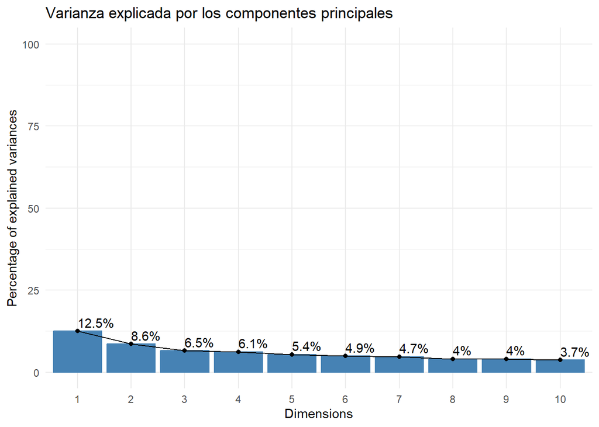

```r
## Represento el porcentaje de varianza explicado por cada componente principal.
## Este gráfico me ayuda a identificar qué componentes concentran más información.

grafico_varianza <- fviz_eig(
  pca_genes,
  addlabels = TRUE,
  ylim = c(0, 100)
) +
  ggtitle("Varianza explicada por los componentes principales") +
  theme_minimal()

grafico_varianza
```

## Resultado de la varianza

El gráfico muestra que PC1 explica el 12,5 % de la variabilidad y PC2 el 8,6 %. A partir de la tercera componente, el porcentaje explicado disminuye de forma gradual y no se observa un “codo” muy marcado. Esto indica que la información de los genes está repartida entre varias componentes y no se concentra únicamente en las dos primeras. Las seis primeras componentes explican aproximadamente el 43,9 % de la variabilidad total.

## 1.23 Coordenadas, Cos2, contribuciones y tabla PCA cargas

```r
## Extraigo las coordenadas, la calidad de representación
## y las contribuciones de las variables génicas en el PCA.

variables_pca <- get_pca_var(pca_genes)

## Reviso las coordenadas de los genes.

head(variables_pca$coord)
```

```
##                Dim.1       Dim.2       Dim.3       Dim.4       Dim.5
## ADCY3    0.711952689 -0.15359180  0.14802015 -0.14325165  0.08099616
## AGRP     0.142234697  0.16008270  0.15971259  0.32280213 -0.31155977
## ANKRD27 -0.320431041 -0.30628766  0.01855168 -0.45722196  0.08434378
## ANO4     0.782947817 -0.05421525  0.04079288  0.06094012 -0.14437550
## BDNF     0.008256813  0.32708718 -0.14679571  0.13786402  0.41052919
## CADM1   -0.183185305 -0.14840722 -0.09419763  0.33017170 -0.31596349
##               Dim.6       Dim.7       Dim.8       Dim.9      Dim.10      Dim.11
## ADCY3   -0.08944860  0.23830370 -0.24610273  0.05375529  0.03380222  0.22698094
## AGRP    -0.28997419 -0.44628152 -0.01477002 -0.25575680 -0.06036621 -0.03293507
## ANKRD27  0.08602916 -0.15124698 -0.22259908 -0.09165563  0.34335300 -0.02683798
## ANO4    -0.17161609  0.08386624  0.00983677  0.04469618  0.22995359 -0.17592249
## BDNF    -0.31703178 -0.17360807  0.18423621 -0.03669463  0.26954420  0.43376112
## CADM1    0.39380420  0.27573674  0.26739927 -0.10717090  0.21337931  0.10086776
##              Dim.12       Dim.13       Dim.14       Dim.15      Dim.16
## ADCY3   -0.12470429  0.001450155 0.0007482986  0.108336662  0.03718639
## AGRP    -0.16405134  0.212931777 0.0069760183  0.031534799 -0.03274654
## ANKRD27 -0.11049226 -0.199766795 0.0777639805  0.009840969  0.13374805
## ANO4    -0.02397871 -0.055049776 0.0730674895  0.041647237  0.12258336
## BDNF     0.00366143  0.130265577 0.2491273808  0.033658684  0.17834260
## CADM1   -0.08122415  0.255764754 0.1199330221 -0.170151189  0.12591501
##              Dim.17       Dim.18      Dim.19       Dim.20      Dim.21
## ADCY3   -0.02064546 -0.301045012  0.07872009  0.017663547  0.01664134
## AGRP    -0.22853868  0.292157259  0.13267675  0.070705741 -0.08729006
## ANKRD27  0.10282566 -0.008721134  0.33319739 -0.006372221 -0.01417704
## ANO4     0.17870653  0.023628345 -0.12102002  0.037541169 -0.12026407
## BDNF    -0.11250205 -0.071939987 -0.11510094 -0.004876607  0.08472497
## CADM1    0.25087434  0.153922107  0.05286362 -0.091263952 -0.04545986
##              Dim.22      Dim.23      Dim.24      Dim.25      Dim.26
## ADCY3    0.07157416 -0.03909030 -0.06210719 -0.02021185 -0.03683021
## AGRP    -0.16410722 -0.13252615  0.11443814  0.08802020 -0.06244573
## ANKRD27  0.04890441  0.29945182 -0.02128999  0.16925725  0.02270614
## ANO4     0.12504372  0.01206535 -0.01111809 -0.14623735  0.15319521
## BDNF     0.15694423  0.02945793 -0.14293678  0.05211705  0.05227786
## CADM1    0.09557964  0.07968563  0.04676640  0.07031486 -0.21734144
##               Dim.27       Dim.28      Dim.29      Dim.30      Dim.31
## ADCY3    0.121506252  0.115314830  0.05925113 -0.03430852 -0.17527844
## AGRP     0.200458183  0.014703219 -0.03177659 -0.01522730 -0.10751401
## ANKRD27  0.120041474 -0.142614990 -0.09565394 -0.06123292 -0.09032710
## ANO4     0.117282700  0.032932553 -0.10964301 -0.03638644  0.13258174
## BDNF     0.100570343 -0.001819894  0.16442066  0.05843842  0.01857994
## CADM1   -0.006569595  0.076104641  0.16059485 -0.13105964 -0.01792026
##               Dim.32      Dim.33       Dim.34      Dim.35       Dim.36
## ADCY3   -0.007113245  0.14341227  0.069174647 -0.07756224 -0.067685803
## AGRP     0.007351341 -0.01536339  0.082317241  0.02598568  0.027684468
## ANKRD27 -0.019790791 -0.05033971 -0.012364794  0.03877909  0.004209808
## ANO4    -0.041547521 -0.15914280  0.054924522 -0.07164424  0.026602236
## BDNF     0.032881525 -0.01515555 -0.053562774  0.05866794  0.077432632
## CADM1    0.045072433 -0.04358991  0.005298755 -0.04988875 -0.019221205
##              Dim.37
## ADCY3   0.037070982
## AGRP    0.025127157
## ANKRD27 0.004016755
## ANO4    0.065368118
## BDNF    0.030618645
## CADM1   0.008655333
```

```r
## Reviso la calidad de representación de los genes.

head(variables_pca$cos2)
```

```
##                 Dim.1       Dim.2        Dim.3       Dim.4       Dim.5
## ADCY3   0.50687663162 0.023590441 0.0219099639 0.020521035 0.006560378
## AGRP    0.02023070917 0.025626470 0.0255081118 0.104201213 0.097069491
## ANKRD27 0.10267605190 0.093812128 0.0003441647 0.209051917 0.007113873
## ANO4    0.61300728488 0.002939294 0.0016640594 0.003713698 0.020844285
## BDNF    0.00006817495 0.106986022 0.0215489797 0.019006489 0.168534215
## CADM1   0.03355685612 0.022024704 0.0088731933 0.109013351 0.099832928
##               Dim.6       Dim.7         Dim.8       Dim.9     Dim.10
## ADCY3   0.008001053 0.056788654 0.06056655532 0.002889631 0.00114259
## AGRP    0.084085029 0.199167191 0.00021815358 0.065411543 0.00364408
## ANKRD27 0.007401016 0.022875649 0.04955035127 0.008400755 0.11789128
## ANO4    0.029452083 0.007033546 0.00009676205 0.001997749 0.05287866
## BDNF    0.100509152 0.030139763 0.03394298144 0.001346496 0.07265408
## CADM1   0.155081748 0.076030748 0.07150236770 0.011485601 0.04553073
##               Dim.11        Dim.12        Dim.13          Dim.14        Dim.15
## ADCY3   0.0515203478 0.01555115893 0.00000210295 0.0000005599508 0.01173683223
## AGRP    0.0010847187 0.02691284369 0.04533994168 0.0000486648320 0.00099444354
## ANKRD27 0.0007202774 0.01220853872 0.03990677224 0.0060472366587 0.00009684466
## ANO4    0.0309487233 0.00057497832 0.00303047786 0.0053388580179 0.00173449234
## BDNF    0.1881487117 0.00001340607 0.01696912064 0.0620644518744 0.00113290703
## CADM1   0.0101743055 0.00659736326 0.06541560959 0.0143839297890 0.02895142721
##              Dim.16       Dim.17        Dim.18      Dim.19       Dim.20
## ADCY3   0.001382828 0.0004262349 0.09062809901 0.006196853 0.0003120009
## AGRP    0.001072336 0.0522299305 0.08535586379 0.017603121 0.0049993018
## ANKRD27 0.017888540 0.0105731158 0.00007605818 0.111020499 0.0000406052
## ANO4    0.015026680 0.0319360256 0.00055829869 0.014645846 0.0014093394
## BDNF    0.031806083 0.0126567119 0.00517536176 0.013248227 0.0000237813
## CADM1   0.015854591 0.0629379333 0.02369201503 0.002794562 0.0083291090
##               Dim.21      Dim.22       Dim.23       Dim.24      Dim.25
## ADCY3   0.0002769344 0.005122861 0.0015280513 0.0038573034 0.000408519
## AGRP    0.0076195550 0.026931180 0.0175631804 0.0130960889 0.007747555
## ANKRD27 0.0002009886 0.002391642 0.0896713952 0.0004532635 0.028648017
## ANO4    0.0144634466 0.015635933 0.0001455726 0.0001236120 0.021385363
## BDNF    0.0071783201 0.024631493 0.0008677695 0.0204309240 0.002716186
## CADM1   0.0020665991 0.009135468 0.0063498002 0.0021870960 0.004944180
##               Dim.26        Dim.27         Dim.28      Dim.29       Dim.30
## ADCY3   0.0013564647 0.01476376924 0.013297509964 0.003510696 0.0011770743
## AGRP    0.0038994689 0.04018348327 0.000216184636 0.001009752 0.0002318707
## ANKRD27 0.0005155689 0.01440995549 0.020339035435 0.009149676 0.0037494704
## ANO4    0.0234687732 0.01375523182 0.001084553076 0.012021589 0.0013239727
## BDNF    0.0027329742 0.01011439394 0.000003312014 0.027034154 0.0034150486
## CADM1   0.0472372997 0.00004315958 0.005791916333 0.025790705 0.0171766299
##               Dim.31        Dim.32       Dim.33        Dim.34       Dim.35
## ADCY3   0.0307225307 0.00005059825 0.0205670794 0.00478513177 0.0060159017
## AGRP    0.0115592620 0.00005404222 0.0002360337 0.00677612815 0.0006752557
## ANKRD27 0.0081589852 0.00039167541 0.0025340864 0.00015288814 0.0015038175
## ANO4    0.0175779187 0.00172619648 0.0253264319 0.00301670315 0.0051328970
## BDNF    0.0003452142 0.00108119466 0.0002296906 0.00286897078 0.0034419273
## CADM1   0.0003211358 0.00203152426 0.0019000800 0.00002807681 0.0024888871
##                Dim.36        Dim.37
## ADCY3   0.00458136795 0.00137425768
## AGRP    0.00076642977 0.00063137400
## ANKRD27 0.00001772248 0.00001613432
## ANO4    0.00070767896 0.00427299080
## BDNF    0.00599581248 0.00093750139
## CADM1   0.00036945474 0.00007491480
```

```r
## Reviso las contribuciones de los genes.

head(variables_pca$contrib)
```

```
##                Dim.1      Dim.2      Dim.3     Dim.4     Dim.5     Dim.6
## ADCY3   10.975489447 0.74468981 0.90735679 0.9045377 0.3310612 0.4423738
## AGRP     0.438059127 0.80896204 1.05636679 4.5930396 4.8984895 4.6490144
## ANKRD27  2.223262731 2.96140870 0.01425288 9.2147077 0.3589926 0.4091980
## ANO4    13.273555272 0.09278598 0.06891365 0.1636945 1.0518806 1.6283892
## BDNF     0.001476204 3.37727480 0.89240735 0.8377787 8.5048667 5.5570950
## CADM1    0.726612547 0.69526352 0.36746533 4.8051516 5.0379428 8.5743834
##              Dim.7       Dim.8      Dim.9     Dim.10      Dim.11      Dim.12
## ADCY3    3.2537607 4.050921511 0.19695803 0.08369959  4.13812290 1.296567324
## AGRP    11.4114762 0.014590941 4.45846832 0.26694437  0.08712479 2.243840081
## ANKRD27  1.3106824 3.314115897 0.57259774 8.63603931  0.05785280 1.017878631
## ANO4     0.4029938 0.006471814 0.13616710 3.87358699  2.48580660 0.047938427
## BDNF     1.7268868 2.270235659 0.09177751 5.32222105 15.11213579 0.001117722
## CADM1    4.3562550 4.782350224 0.78286165 3.33532020  0.81720191 0.550050685
##               Dim.13        Dim.14    Dim.15    Dim.16     Dim.17       Dim.18
## ADCY3   0.0001928073 0.00005262724 1.2679997 0.1540660 0.04903803 11.174063466
## AGRP    4.1569581546 0.00457378728 0.1074356 0.1194729 6.00901812 10.524019037
## ANKRD27 3.6588221364 0.56835240154 0.0104627 1.9930291 1.21642980  0.009377654
## ANO4    0.2778470632 0.50177509948 0.1873875 1.6741786 3.67421811  0.068835880
## BDNF    1.5558009517 5.83315690526 0.1223947 3.5436346 1.45614612  0.638100340
## CADM1   5.9975805357 1.35188045394 3.1277946 1.7664192 7.24096658  2.921125816
##             Dim.19      Dim.20     Dim.21    Dim.22      Dim.23     Dim.24
## ADCY3    0.8345039 0.045451913 0.04224213 0.8705178  0.28805575 0.80008688
## AGRP     2.3705376 0.728292268 1.16224752 4.5763633  3.31086731 2.71640772
## ANKRD27 14.9506598 0.005915316 0.03065776 0.4064070 16.90411902 0.09401651
## ANO4     1.9722940 0.205310863 2.20617935 2.6569839  0.02744216 0.02563976
## BDNF     1.7840826 0.003464431 1.09494384 4.1855819  0.16358483 4.23780871
## CADM1    0.3763318 1.213374579 0.31522833 1.5523723  1.19701248 0.45365028
##             Dim.25     Dim.26      Dim.27     Dim.28    Dim.29     Dim.30
## ADCY3   0.09521767  0.3505892  4.45755318 4.36129822 1.2839477 0.48965717
## AGRP    1.80580141  1.0078490 12.13240405 0.07090393 0.3692911 0.09645708
## ANKRD27 6.67728408  0.1332529  4.35072791 6.67076763 3.3462612 1.55976140
## ANO4    4.98450366  6.0656925  4.15305037 0.35571016 4.3965904 0.55076618
## BDNF    0.63308914  0.7063591  3.05378987 0.00108627 9.8870540 1.42064357
## CADM1   1.15239027 12.2088587  0.01303096 1.89962440 9.4322940 7.14539420
##             Dim.31     Dim.32     Dim.33     Dim.34    Dim.35     Dim.36
## ADCY3   13.5070223 0.02650736 13.9389567 4.02142113 6.5324567 5.50169908
## AGRP     5.0819775 0.02831158  0.1599675 5.69465299 0.7332364 0.92039453
## ANKRD27  3.5870611 0.20519049  1.7174301 0.12848708 1.6329426 0.02128268
## ANO4     7.7280528 0.90431797 17.1645196 2.53523506 5.5736329 0.84984151
## BDNF     0.1517719 0.56641510  0.1556686 2.41108088 3.7374681 7.20028524
## CADM1    0.1411859 1.06427275  1.2877440 0.02359573 2.7025953 0.44367290
##             Dim.37
## ADCY3   2.58186385
## AGRP    1.18618344
## ANKRD27 0.03031208
## ANO4    8.02781065
## BDNF    1.76131521
## CADM1   0.14074493
```

```r
## Convierto las coordenadas de las variables en una tabla.
## Estas coordenadas representan las cargas de cada gen.

tabla_pca_cargas <- as.data.frame(variables_pca$coord) %>%
  tibble::rownames_to_column("Variable") %>%
  select(
    Variable,
    Dim.1,
    Dim.2,
    Dim.3,
    Dim.4,
    Dim.5,
    Dim.6
  ) %>%
  rename(
    PC1 = Dim.1,
    PC2 = Dim.2,
    PC3 = Dim.3,
    PC4 = Dim.4,
    PC5 = Dim.5,
    PC6 = Dim.6
  ) %>%
  mutate(
    across(
      PC1:PC6,
      ~ round(.x, 3)
    )
  )

tabla_pca_cargas
```

```
##    Variable    PC1    PC2    PC3    PC4    PC5    PC6
## 1     ADCY3  0.712 -0.154  0.148 -0.143  0.081 -0.089
## 2      AGRP  0.142  0.160  0.160  0.323 -0.312 -0.290
## 3   ANKRD27 -0.320 -0.306  0.019 -0.457  0.084  0.086
## 4      ANO4  0.783 -0.054  0.041  0.061 -0.144 -0.172
## 5      BDNF  0.008  0.327 -0.147  0.138  0.411 -0.317
## 6     CADM1 -0.183 -0.148 -0.094  0.330 -0.316  0.394
## 7     CADM2 -0.020  0.581  0.080  0.266  0.219  0.312
## 8     CALCR -0.009  0.090  0.123  0.332 -0.253  0.243
## 9      CNR1  0.193 -0.073 -0.183 -0.288 -0.209 -0.015
## 10   CREBRF  0.012 -0.185  0.511  0.102  0.210  0.153
## 11     DPP9  0.306 -0.092  0.138  0.430  0.516 -0.102
## 12      FTO -0.185 -0.443  0.470 -0.071  0.285 -0.138
## 13     GIPR  0.179  0.122  0.209  0.117  0.511  0.517
## 14   GPR151 -0.284 -0.374 -0.093 -0.272 -0.119 -0.023
```

[output cut: 23 more lines]

```r
## Convierto la tabla a flextable para mejorar su presentación.

tabla_cargas_flex <- flextable(tabla_pca_cargas) %>%
  autofit() %>%
  fontsize(size = 8, part = "all")

tabla_cargas_flex
```

| Variable | PC1 | PC2 | PC3 | PC4 | PC5 | PC6 |
| --- | --- | --- | --- | --- | --- | --- |
| ADCY3 | 0.712 | -0.154 | 0.148 | -0.143 | 0.081 | -0.089 |
| AGRP | 0.142 | 0.160 | 0.160 | 0.323 | -0.312 | -0.290 |
| ANKRD27 | -0.320 | -0.306 | 0.019 | -0.457 | 0.084 | 0.086 |
| ANO4 | 0.783 | -0.054 | 0.041 | 0.061 | -0.144 | -0.172 |
| BDNF | 0.008 | 0.327 | -0.147 | 0.138 | 0.411 | -0.317 |
| CADM1 | -0.183 | -0.148 | -0.094 | 0.330 | -0.316 | 0.394 |
| CADM2 | -0.020 | 0.581 | 0.080 | 0.266 | 0.219 | 0.312 |
| CALCR | -0.009 | 0.090 | 0.123 | 0.332 | -0.253 | 0.243 |
| CNR1 | 0.193 | -0.073 | -0.183 | -0.288 | -0.209 | -0.015 |
| CREBRF | 0.012 | -0.185 | 0.511 | 0.102 | 0.210 | 0.153 |
| DPP9 | 0.306 | -0.092 | 0.138 | 0.430 | 0.516 | -0.102 |
| FTO | -0.185 | -0.443 | 0.470 | -0.071 | 0.285 | -0.138 |
| GIPR | 0.179 | 0.122 | 0.209 | 0.117 | 0.511 | 0.517 |
| GPR151 | -0.284 | -0.374 | -0.093 | -0.272 | -0.119 | -0.023 |
| GPR75 | -0.252 | 0.132 | -0.153 | -0.058 | 0.027 | -0.452 |
| KIAA0586 | 0.115 | -0.440 | -0.406 | 0.242 | -0.125 | 0.230 |
| KIAA1109 | 0.367 | -0.248 | 0.260 | -0.167 | -0.242 | 0.257 |
| KSR2 | -0.141 | 0.463 | 0.296 | -0.202 | -0.269 | 0.251 |
| LEP | -0.316 | 0.405 | 0.146 | -0.197 | 0.315 | 0.008 |
| LEPR | 0.721 | 0.103 | -0.111 | -0.247 | 0.020 | -0.127 |
| MC4R | -0.483 | -0.261 | 0.136 | 0.451 | 0.017 | -0.245 |
| MRAP2 | 0.036 | -0.029 | -0.656 | 0.042 | 0.166 | -0.061 |
| NRP1 | 0.000 | -0.495 | -0.214 | 0.117 | 0.103 | 0.236 |
| NRP2 | -0.188 | -0.090 | 0.181 | 0.211 | -0.292 | -0.366 |
| NTRK2 | -0.312 | 0.597 | -0.043 | -0.162 | -0.002 | -0.042 |
| PCSK1 | 0.627 | -0.243 | -0.030 | -0.095 | -0.055 | 0.096 |
| PDE3B | -0.328 | -0.074 | 0.298 | 0.190 | -0.377 | 0.146 |
| PHIP | -0.128 | -0.445 | 0.393 | -0.252 | 0.154 | -0.012 |
| POMC | 0.801 | -0.069 | 0.100 | -0.022 | 0.040 | -0.005 |
| PPARG | -0.167 | -0.192 | -0.255 | -0.409 | 0.125 | 0.057 |
| ROBO1 | -0.116 | 0.296 | 0.202 | -0.630 | -0.095 | 0.167 |
| SH2B1 | 0.579 | -0.019 | 0.360 | -0.071 | -0.084 | -0.245 |
| SIM1 | -0.325 | -0.332 | 0.217 | -0.087 | 0.352 | -0.156 |
| SPARC | 0.142 | -0.033 | -0.379 | -0.044 | 0.193 | 0.274 |
| TMEM18 | 0.279 | 0.356 | 0.291 | 0.130 | 0.019 | 0.163 |
| UBR2 | -0.255 | -0.180 | 0.231 | -0.107 | -0.137 | -0.072 |
| UHMK1 | 0.202 | 0.382 | -0.029 | -0.128 | -0.082 | -0.191 |

```r
## Guardo la tabla como imagen PNG.

save_as_image(
  tabla_cargas_flex,
  path = "tabla_pca_cargas.png"
)
```

```
## [1] "tabla_pca_cargas.png"
```

```r
## También la guardo como CSV para compartirla y reutilizarla.

write.csv(
  tabla_pca_cargas,
  "tabla_pca_cargas.csv",
  row.names = FALSE
)
```

## 1.24 Interpretación de la tabla PCA de cargas

Las cargas indican la relación de cada gen con los componentes principales. Cuanto mayor es el valor absoluto de la carga, mayor es la importancia del gen para definir ese componente. El signo indica la dirección de la asociación, pero no su intensidad.

En PC1 destacaron principalmente POMC con una carga de 0,801, ANO4 con 0,783, LEPR con 0,721, ADCY3 con 0,712, PCSK1 con 0,627 y SH2B1 con 0,579. Todos presentan cargas positivas, por lo que tienden a aumentar conjuntamente a medida que aumenta el score de PC1. Este componente parece representar un patrón común de expresión definido principalmente por estos genes.

En PC2, los genes con mayor peso fueron NTRK2 (0,597) y CADM2 (0,581) en sentido positivo, mientras que NRP1 (-0,495), PHIP (-0,445) y FTO (-0,443) presentaron cargas negativas. Esto indica que PC2 contrapone dos grupos de genes con comportamientos opuestos.

En PC3 destacó MRAP2 con una carga negativa de -0,656, mientras que CREBRF (0,511) y FTO (0,470) presentaron cargas positivas. En PC4, el gen más representativo fue ROBO1 (-0,630), seguido de ANKRD27, MC4R, DPP9 y PPARG. Para PC5 destacaron DPP9, GIPR y BDNF, mientras que PC6 estuvo principalmente definida por GIPR, GPR75, CADM1 y NRP2.

En conjunto, las cargas muestran que cada componente resume patrones diferentes de expresión y que no todos los genes contribuyen de la misma manera a la estructura multivariante del dataset.

## 1.25 Visualización de variables según Cos2

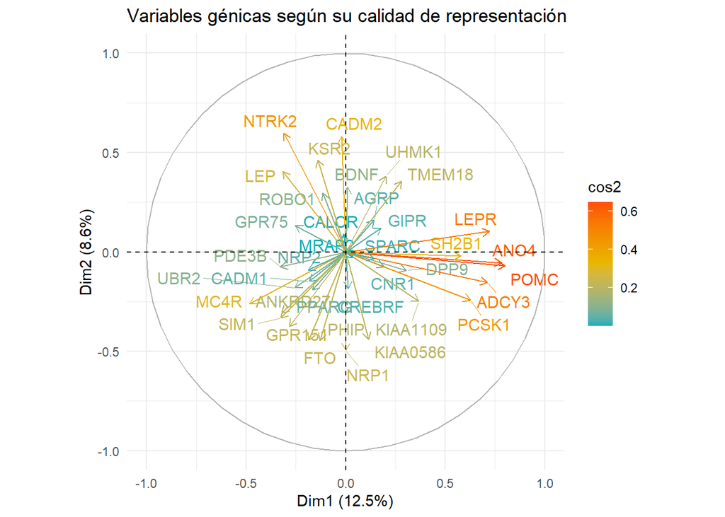

```r
## Represento las variables génicas en el espacio de PC1 y PC2.
## El color indica la calidad de representación de cada variable.

grafico_variables_cos2 <- fviz_pca_var(
  pca_genes,
  axes = c(1, 2),
  col.var = "cos2",
  gradient.cols = c("#00AFBB", "#E7B800", "#FC4E07"),
  repel = TRUE
) +
  ggtitle("Variables génicas según su calidad de representación") +
  theme_minimal()

grafico_variables_cos2
```

## Interpretacion de graficos segun Cos2

El gráfico muestra cómo se representan los genes en el plano formado por PC1 y PC2. Los genes con colores más cálidos y flechas más largas tienen una mejor calidad de representación. En PC1 destacan especialmente POMC, ADCY3, LEPR, ANO4 y PCSK1, mientras que en PC2 sobresalen NTRK2 y CADM2. Los genes cercanos al centro tienen una representación más débil en estas dos componentes. En conjunto, el gráfico confirma que distintos grupos de genes contribuyen de manera diferente a PC1 y PC2.

## 1.26 Contribución de los genes a los componentes

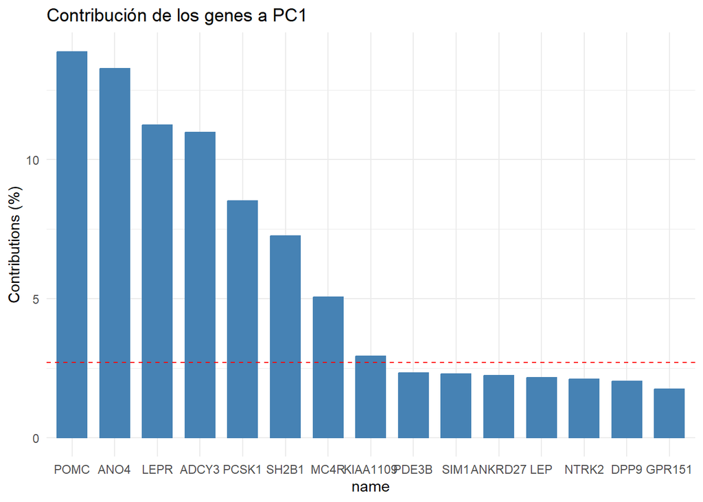

```r
## Muestro los genes que más contribuyen a la primera componente.

contribucion_pc1 <- fviz_contrib(
  pca_genes,
  choice = "var",
  axes = 1,
  top = 15
) +
  ggtitle("Contribución de los genes a PC1") +
  theme_minimal()

contribucion_pc1
```

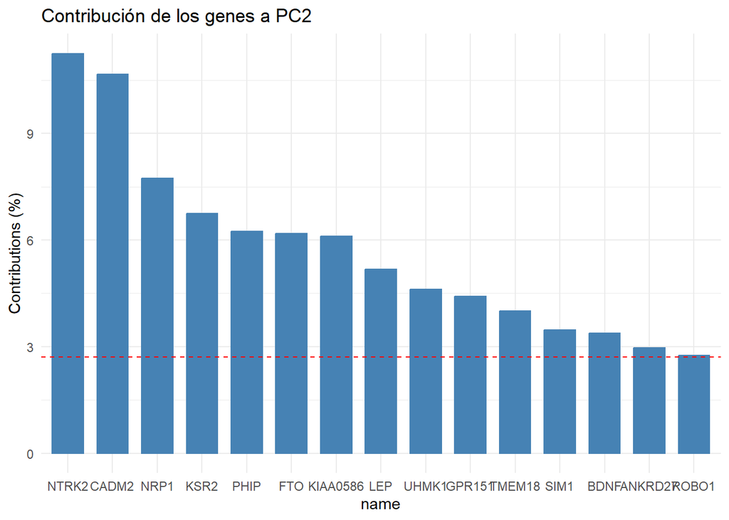

```r
## Muestro los genes que más contribuyen a la segunda componente.

contribucion_pc2 <- fviz_contrib(
  pca_genes,
  choice = "var",
  axes = 2,
  top = 15
) +
  ggtitle("Contribución de los genes a PC2") +
  theme_minimal()

contribucion_pc2
```

## Resultados de los componentes

En PC1, los genes que más contribuyen son POMC, ANO4, LEPR, ADCY3, PCSK1 y SH2B1. Todos superan claramente la contribución media marcada por la línea roja, por lo que son los genes más importantes para definir esta componente. En PC2, destacan principalmente NTRK2, CADM2, NRP1, KSR2, PHIP, FTO y KIAA0586. También se sitúan por encima de la contribución media, indicando que tienen un peso relevante en la construcción de PC2. En conjunto, PC1 y PC2 están definidas por grupos distintos de genes, lo que sugiere que cada componente resume patrones diferentes de expresión génica.

## 1.27 HEATMAP CORRELACIONES DE SPERAMAN

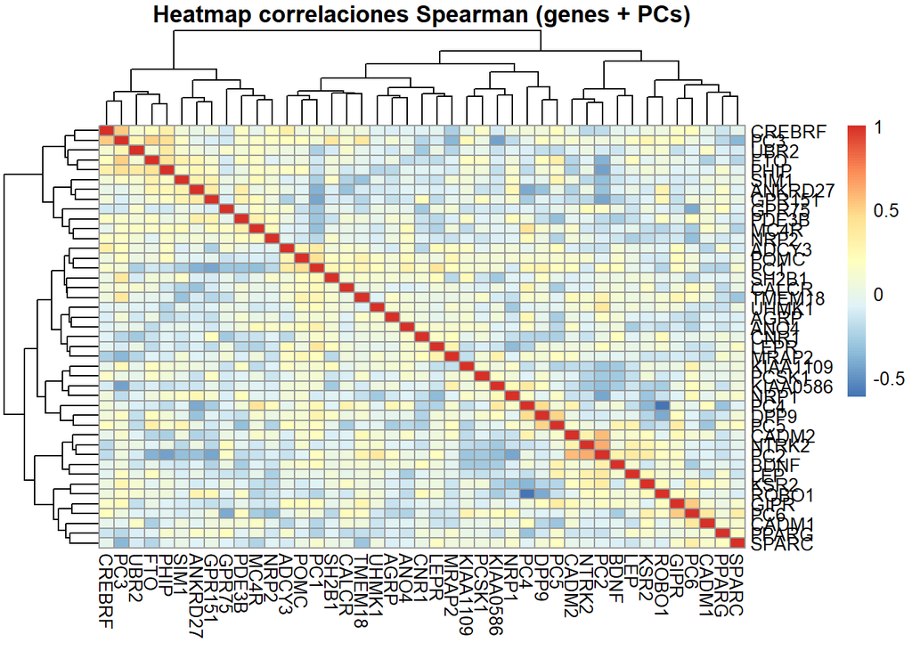

```r
#Se construye un heatmap con las correlaciones de Spearman entre las variables génicas y los primeras seis componentes principales, con el objetivo de observar posibles asociaciones entre genes o grupos de genes y los componentes principales.


# Matriz combinada genes + PCs
mat <- cbind(datos_genes, pca_genes$x[, 1:6])
cor_mat <- cor(mat, method = "spearman", use = "pairwise.complete.obs")

# Visualizar Heatmap

pheatmap(
  cor_mat,
  clustering_method = "ward.D2",
  main = "Heatmap correlaciones Spearman (genes + PCs)"
)
```

## 1.28 Interpretación del Heatmap de correlaciones de Spearman

El análisis de correlaciones de Spearman entre genes y componentes principales muestra patrones diferenciados de asociación entre la expresión génica y los ejes de variabilidad capturados por el PCA.

### 1.28.1 Genes fuertemente asociados a PC2

Los genes CADM2 y NTRK2 presentan correlaciones positivas moderadas-altas con PC2 (ρ entre 0.5 y 1).

Esto indica que PC2 está fuertemente influido por la variación conjunta de estos genes. Ambos podrían formar parte de un mismo eje funcional o biológico y sugiere un posible módulo de coexpresión relacionado con ese componente.

### 1.28.2 Genes asociados a PC3

Los genes CREBRF y UBR2 muestran correlaciones positivas elevadas con PC3 (ρ entre 0.5 y 1).

Esto indica que PC3 recoge un patrón de expresión asociado a estos genes. Podría representar una vía biológica diferente a la capturada por PC2 y refuerza la idea de que los componentes del PCA no son aleatorios, sino estructurados biológicamente.

### 1.28.3 Gen asociado a PC6

El gen GIPR presenta una correlación positiva fuerte con PC6 (ρ entre 0.5 y 1).

Esto indica que PC6 parece estar dominado por variación específica de un único gen o muy pocos genes. Sugiere un componente más “específico” o de menor varianza global.

### 1.28.4 Asociación negativa con PC4

El gen ROBO1 muestra una correlación negativa fuerte con PC4 (ρ entre −0.5 y −1).

Esto indica que este gen se comporta en dirección opuesta al resto de variables que definen PC4 y que podría representar un eje de contraste biológico donde ROBO1 actúa como marcador inverso.

### 1.28.5 Resto de genes

El resto de genes muestran correlaciones débiles o moderadas (ρ entre −0.5 y 0.5) con todos los componentes.

Esto indica que no contribuyen de forma dominante a ningún eje principal y refuerza el hecho de que solo un subconjunto de genes explica la estructura principal del dataset.

### 1.28.6 Conclusión global

En conjunto, el heatmap de Spearman revela que la estructura del PCA está impulsada por subconjuntos específicos de genes. PC2 y PC3 están asociados a grupos de genes concretos (CADM2–NTRK2 y CREBRF–UBR2, respectivamente), mientras que PC6 parece capturar una señal más específica dominada por GIPR. Por otro lado, PC4 muestra una relación inversa con ROBO1, sugiriendo un eje de variación con comportamiento opuesto para este gen. El resto de genes presentan correlaciones débiles, indicando que no contribuyen de forma predominante a los principales ejes de variabilidad.

## 1.29 ANÁLISIS DE EXPRESIÓN GÉNICA POR TERCILES DEL PCA

En este bloque se compara la expresión génica según los patrones de variabilidad identificados en el PCA, clasificando a los individuos en terciles (bajo, medio, alto) para PC1, PC2 y PC3. Se integran estos grupos con los datos originales y se generan tablas descriptivas por componente, utilizando mediana y rango intercuartílico. Las diferencias entre grupos se evalúan mediante el test de Kruskal-Wallis. Como resultado, se obtiene una tabla combinada que permite identificar genes asociados a los principales ejes de variación del conjunto de datos, lo que permite identificar genes cuya expresión se asocia a los patrones de variabilidad capturados por el PCA.

El análisis por terciles de los componentes principales identificó múltiples genes con diferencias significativas de expresión a lo largo de los ejes de variabilidad. El componente PC2 concentró el mayor número de asociaciones estadísticas significativas, incluyendo genes clave en la regulación metabólica y energética como FTO, LEP, KSR2 y NTRK2, lo que sugiere que este componente refleja un eje biológico relacionado con la homeostasis energética y el riesgo de obesidad. El PC1 mostró asociaciones adicionales con genes implicados en el control neuroendocrino del apetito, como POMC y MC4R, indicando un papel relevante aunque más heterogéneo. Por su parte, el PC3 capturó un conjunto más reducido de genes, destacando FTO, CREBRF y SH2B1, lo que sugiere la presencia de un eje metabólico secundario. En conjunto, los resultados evidencian que los principales componentes del PCA reflejan gradientes biológicos relacionados con el metabolismo energético y la regulación del apetito.

```r
# CREACIÓN DE TERCILES DEL PCA

## Clasificamos cada individuo en “bajo / medio / alto” según su posición en PC1, PC2 y PC3

## Extraemos los scores del PCA (coordenadas de cada individuo en los componentes)

scores_pca <- as.data.frame(pca_genes$x)

## Creamos terciles (T1, T2, T3) para cada componente principal
## Dividimos los datos en 3 grupos según percentiles 33% y 66%

scores_pca <- scores_pca %>%
  mutate(

    PC1_t = cut(
      PC1,
      breaks = quantile(PC1, probs = c(0, 1/3, 2/3, 1)),
      include.lowest = TRUE,
      labels = c("T1", "T2", "T3")
    ),

    PC2_t = cut(
      PC2,
      breaks = quantile(PC2, probs = c(0, 1/3, 2/3, 1)),
      include.lowest = TRUE,
      labels = c("T1", "T2", "T3")
    ),

    PC3_t = cut(
      PC3,
      breaks = quantile(PC3, probs = c(0, 1/3, 2/3, 1)),
      include.lowest = TRUE,
      labels = c("T1", "T2", "T3")
    )
  )


# UNIÓN DE DATOS ORIGINALES Y TERCILES DEL PCA
# Usamos expresión génica original (sin transformar) y agrupamos por terciles del PCA
# Nos quedamos solo con los genes + los grupos de PCA

df_final <- cbind(
  simpson_df[, genes_simpson],   # datos originales de genes
  scores_pca[, c("PC1_t", "PC2_t", "PC3_t")]  # terciles
)

# Conversión explícita de genes a numéricos

df_final <- df_final %>%
  mutate(across(all_of(genes_simpson), ~ as.numeric(as.character(.))))

str(df_final)
```

```
## 'data.frame':    59 obs. of  40 variables:
##  $ ADCY3   : num  0.858 2.04 -0.189 -0.54 -0.17 ...
##  $ AGRP    : num  0.865 0.253 -2.337 0.662 0.233 ...
##  $ ANKRD27 : num  -0.989 -0.786 0.818 -0.18 -0.353 ...
##  $ ANO4    : num  2.162 0.612 -0.161 -0.31 -0.55 ...
##  $ BDNF    : num  -0.696 -0.841 -0.889 1.171 1.213 ...
##  $ CADM1   : num  -0.5649 -1.2616 0.9951 -0.4105 -0.0521 ...
##  $ CADM2   : num  -0.82 -0.718 -0.693 1.239 1.165 ...
##  $ CALCR   : num  -0.26 -0.348 1.02 -0.567 -0.163 ...
##  $ CNR1    : num  1.33 0.175 -0.475 0.757 -1.942 ...
##  $ CREBRF  : num  0.735 -1.35 0.617 -1.547 0.792 ...
##  $ DPP9    : num  1.395 0.135 -0.16 -0.264 -1.152 ...
##  $ FTO     : num  -0.668 -0.284 0.599 -0.49 -0.316 ...
##  $ GIPR    : num  1.415 -0.643 -0.669 -0.597 -0.18 ...
##  $ GPR151  : num  -1.194 -0.166 0.483 0.359 -1.664 ...
```

[output cut: 26 more lines]

```r
#  TABLA DESCRIPTIVA - PC1
tabla_PC1 <- df_final %>%

  # Eliminamos otros grupos para que no interfieran

  select(-PC2_t, -PC3_t) %>%

  # Creamos la tabla

  tbl_summary(
    by = PC1_t,   # Agrupamos por terciles

    type = all_of(genes_simpson) ~ "continuous",

    # Usamos mediana y rango intercuartílico
    # (porque la mayoría de genes no siguen distribución normal)

    statistic = all_continuous() ~ "{median} ({p25} - {p75})",

    # Número de decimales

    digits = all_continuous() ~ 1
  ) %>%

  # Añadimos comparación estadística (Kruskal-Wallis)

  add_p(test = all_continuous() ~ "kruskal.test")


# TABLA DESCRIPTIVA - PC2

tabla_PC2 <- df_final %>%

  select(-PC1_t, -PC3_t) %>%

  tbl_summary(
    by = PC2_t,
    type = all_of(genes_simpson) ~ "continuous",
    statistic = all_continuous() ~ "{median} ({p25} - {p75})",
    digits = all_continuous() ~ 1
  ) %>%

  add_p(test = all_continuous() ~ "kruskal.test")


# TABLA DESCRIPTIVA - PC3
tabla_PC3 <- df_final %>%

  select(-PC1_t, -PC2_t) %>%

  tbl_summary(
    by = PC3_t,
    type = all_of(genes_simpson) ~ "continuous",
    statistic = all_continuous() ~ "{median} ({p25} - {p75})",
    digits = all_continuous() ~ 1
  ) %>%

  add_p(test = all_continuous() ~ "kruskal.test")


# COMBINAR TABLAS

tabla_combinada <- tbl_merge(
  tbls = list(tabla_PC1, tabla_PC2, tabla_PC3),
  tab_spanner = c("**PC1**", "**PC2**", "**PC3**")
)

#  MOSTRAR TABLA COMBINADA

tabla_combinada
```

| **Characteristic** | **PC1** **T1** N = 20<sup>1</sup> | **PC1** **T2** N = 19<sup>1</sup> | **PC1** **T3** N = 20<sup>1</sup> | **PC1** **p-value**<sup>2</sup> | **PC2** **T1** N = 20<sup>1</sup> | **PC2** **T2** N = 19<sup>1</sup> | **PC2** **T3** N = 20<sup>1</sup> | **PC2** **p-value**<sup>2</sup> | **PC3** **T1** N = 20<sup>1</sup> | **PC3** **T2** N = 19<sup>1</sup> | **PC3** **T3** N = 20<sup>1</sup> | **PC3** **p-value**<sup>2</sup> |
| --- | --- | --- | --- | --- | --- | --- | --- | --- | --- | --- | --- | --- |
| ADCY3 | -0.8 (-0.9 - -0.5) | -0.5 (-0.8 - -0.2) | -0.2 (-0.8 - -0.2) | 0.016 | -0.2 (-0.8 - -0.2) | -0.5 (-0.8 - -0.2) | -0.5 (-0.8 - -0.2) | 0.5 | -0.5 (-0.9 - -0.4) | -0.5 (-0.8 - -0.2) | -0.4 (-0.8 - -0.2) | 0.4 |
| AGRP | 0.2 (-0.2 - 0.5) | 0.2 (-0.2 - 0.3) | 0.2 (-0.2 - 0.7) | 0.7 | 0.2 (-0.2 - 0.3) | 0.2 (0.2 - 0.3) | 0.2 (0.0 - 0.7) | 0.5 | 0.2 (-0.2 - 0.6) | 0.3 (0.2 - 0.7) | 0.2 (-0.2 - 0.5) | 0.7 |
| ANKRD27 | 0.8 (-0.2 - 0.8) | -0.2 (-0.4 - 2.1) | -0.4 (-0.4 - -0.2) | 0.046 | 0.3 (-0.2 - 2.1) | 0.8 (-0.4 - 0.8) | -0.4 (-0.4 - -0.2) | 0.040 | -0.2 (-0.4 - 1.5) | -0.2 (-0.4 - 0.8) | -0.2 (-0.4 - 2.1) | 0.7 |
| ANO4 | -0.5 (-0.8 - -0.3) | -0.5 (-0.5 - -0.3) | -0.3 (-0.5 - -0.2) | 0.2 | -0.5 (-0.5 - -0.3) | -0.3 (-0.5 - -0.1) | -0.5 (-0.5 - -0.3) | 0.12 | -0.5 (-0.5 - -0.3) | -0.3 (-0.5 - -0.2) | -0.5 (-0.5 - -0.2) | 0.9 |
| BDNF | -0.8 (-0.9 - -0.7) | -0.8 (-0.9 - -0.7) | -0.7 (-0.8 - 1.2) | 0.2 | -0.8 (-0.9 - -0.7) | -0.7 (-0.9 - -0.7) | -0.7 (-0.8 - 1.2) | 0.2 | -0.8 (-0.9 - 0.3) | -0.7 (-0.8 - 1.2) | -0.8 (-0.9 - -0.7) | 0.6 |
| CADM1 | -0.4 (-0.6 - 1.0) | -0.1 (-0.6 - 1.0) | -0.6 (-0.9 - -0.4) | 0.029 | -0.2 (-0.6 - 1.0) | -0.4 (-0.6 - 1.0) | -0.4 (-0.6 - -0.3) | 0.5 | -0.5 (-0.9 - 1.0) | -0.4 (-0.6 - 1.0) | -0.4 (-0.6 - -0.1) | 0.5 |
| CADM2 | -0.7 (-0.7 - -0.6) | -0.7 (-0.7 - 1.2) | -0.6 (-0.7 - 1.2) | 0.4 | -0.7 (-0.8 - -0.7) | -0.7 (-0.7 - 1.2) | 1.2 (-0.6 - 1.2) | <0.001 | -0.6 (-0.7 - -0.6) | -0.7 (-0.7 - 1.2) | -0.6 (-0.7 - 1.2) | 0.4 |
| CALCR | -0.3 (-1.0 - 1.0) | -0.3 (-0.7 - 1.0) | -0.2 (-0.3 - 1.5) | 0.3 | -0.3 (-0.8 - 1.5) | -0.3 (-0.7 - 1.0) | 0.4 (-0.6 - 1.5) | 0.3 | -0.3 (-0.8 - 1.0) | -0.3 (-0.6 - 2.0) | -0.3 (-0.7 - 1.0) | 0.4 |
| CNR1 | -0.2 (-0.3 - 0.7) | -0.2 (-1.9 - 0.7) | -0.2 (-0.3 - 0.7) | 0.7 | -0.2 (-0.3 - 0.7) | -0.2 (-0.3 - 0.7) | -0.2 (-1.1 - 0.7) | >0.9 | 0.7 (-0.3 - 0.7) | -0.2 (-0.3 - 0.7) | -0.3 (-1.9 - 0.7) | 0.2 |
| CREBRF | 0.4 (-1.4 - 0.7) | 0.6 (-1.4 - 0.7) | 0.7 (-1.4 - 0.8) | 0.3 | 0.7 (0.4 - 0.8) | 0.6 (-1.4 - 0.7) | 0.1 (-1.4 - 0.8) | 0.3 | -1.4 (-1.4 - 0.7) | 0.6 (-1.4 - 0.7) | 0.7 (0.6 - 0.8) | 0.001 |
| DPP9 | -1.2 (-1.5 - -0.2) | 0.7 (-0.3 - 0.8) | -0.1 (-0.7 - 0.8) | 0.025 | 0.3 (-0.7 - 0.8) | -0.3 (-1.2 - 0.7) | -0.3 (-1.2 - 0.8) | 0.3 | -0.3 (-1.5 - 0.8) | -0.3 (-1.2 - 0.7) | 0.7 (-0.7 - 0.8) | 0.4 |
| FTO | 0.6 (0.2 - 0.9) | 0.6 (-0.3 - 0.9) | 0.6 (-0.4 - 0.9) | 0.8 | 0.9 (0.6 - 1.7) | 0.6 (-0.3 - 0.9) | -0.3 (-1.4 - 0.9) | 0.025 | 0.6 (-0.3 - 0.6) | 0.6 (-1.4 - 0.9) | 0.9 (0.8 - 1.7) | <0.001 |
| GIPR | -0.4 (-0.8 - 0.0) | 0.0 (-0.2 - 1.6) | -0.2 (-0.6 - 0.7) | 0.042 | -0.2 (-0.6 - 1.5) | -0.2 (-1.0 - 0.0) | -0.2 (-0.2 - 0.0) | 0.4 | -0.2 (-0.6 - 0.0) | -0.2 (-0.6 - 0.0) | 0.0 (-0.4 - 1.6) | 0.13 |
| GPR151 | 0.4 (0.0 - 0.7) | 0.5 (-0.2 - 0.7) | -0.2 (-1.2 - 0.2) | 0.008 | 0.6 (0.3 - 1.0) | -0.2 (-1.2 - 0.5) | -0.2 (-0.7 - 0.4) | 0.002 | 0.3 (-0.2 - 0.7) | 0.1 (-1.2 - 0.5) | 0.2 (-0.2 - 0.6) | 0.5 |
| GPR75 | 0.6 (0.3 - 0.7) | 0.3 (-1.1 - 0.7) | 0.1 (-1.5 - 0.5) | 0.090 | 0.3 (-1.5 - 0.6) | 0.4 (-1.1 - 0.7) | 0.4 (-0.5 - 0.7) | 0.5 | 0.5 (-0.5 - 0.6) | 0.4 (-1.1 - 0.7) | 0.2 (-1.1 - 0.6) | 0.5 |
| KIAA0586 | 0.5 (-0.5 - 0.8) | 0.7 (-0.5 - 0.9) | 0.7 (-0.5 - 0.9) | 0.8 | 0.8 (0.5 - 0.9) | 0.7 (0.5 - 0.9) | -0.5 (-1.4 - 0.8) | 0.053 | 0.9 (0.6 - 0.9) | 0.5 (-0.5 - 0.9) | 0.3 (-0.5 - 0.7) | 0.019 |
| KIAA1109 | -0.5 (-0.7 - 0.4) | -0.5 (-0.7 - 0.3) | -0.5 (-0.7 - 0.4) | 0.8 | -0.1 (-0.5 - 0.4) | -0.5 (-0.7 - 0.3) | -0.6 (-1.6 - -0.1) | 0.028 | -0.5 (-1.1 - -0.5) | -0.5 (-0.7 - 0.4) | -0.1 (-0.7 - 0.4) | 0.3 |
| KSR2 | -0.2 (-0.6 - 0.2) | 0.0 (-0.4 - 0.6) | -0.2 (-0.8 - 0.2) | 0.6 | -0.4 (-0.8 - 0.1) | -0.2 (-0.4 - 0.0) | 0.2 (-0.4 - 2.0) | 0.041 | -0.3 (-0.8 - -0.2) | 0.0 (-0.2 - 0.6) | 0.0 (-0.4 - 0.6) | 0.027 |
| LEP | 1.0 (-0.5 - 1.1) | 1.0 (-0.7 - 1.1) | 1.0 (0.4 - 1.1) | 0.4 | -0.3 (-0.7 - 1.1) | 1.0 (-0.7 - 1.1) | 1.0 (1.0 - 1.1) | 0.022 | 1.0 (-0.7 - 1.1) | 1.0 (-0.3 - 1.1) | 1.0 (-0.5 - 1.1) | 0.5 |
| LEPR | -0.9 (-0.9 - -0.2) | -0.2 (-0.9 - 0.0) | -0.2 (-0.7 - 0.0) | 0.057 | -0.8 (-0.9 - -0.2) | -0.2 (-0.9 - 0.0) | -0.2 (-0.9 - 0.0) | 0.4 | -0.2 (-0.9 - 0.0) | -0.7 (-0.9 - 0.0) | -0.4 (-0.9 - -0.2) | 0.8 |
| MC4R | 0.5 (0.0 - 1.2) | 0.1 (0.0 - 0.9) | -0.5 (-0.5 - 0.5) | 0.039 | 0.9 (-0.2 - 1.1) | 0.1 (0.0 - 1.2) | 0.1 (-0.2 - 0.9) | 0.8 | 0.0 (-0.5 - 0.9) | 0.1 (0.0 - 1.2) | 0.5 (0.0 - 1.1) | 0.4 |
| MRAP2 | -0.2 (-0.5 - -0.2) | -0.2 (-0.5 - -0.2) | -0.2 (-0.3 - -0.1) | 0.2 | -0.2 (-0.5 - -0.2) | -0.2 (-0.5 - -0.2) | -0.3 (-0.5 - -0.2) | 0.9 | -0.2 (-0.4 - 2.4) | -0.2 (-0.5 - -0.2) | -0.3 (-0.5 - -0.2) | 0.070 |
| NRP1 | 0.7 (0.0 - 0.8) | 0.0 (0.0 - 0.7) | 0.0 (-1.6 - 1.0) | 0.7 | 0.7 (0.0 - 1.3) | 0.7 (0.0 - 0.8) | -1.2 (-1.6 - 0.4) | 0.009 | 0.3 (0.0 - 0.8) | 0.2 (-1.6 - 1.3) | 0.0 (-1.4 - 0.7) | 0.5 |
| NRP2 | 0.9 (-1.2 - 0.9) | -0.6 (-1.7 - 0.9) | -0.9 (-1.2 - 0.5) | 0.3 | -0.6 (-1.4 - 0.9) | -0.6 (-1.2 - 0.9) | -0.1 (-1.4 - 0.9) | >0.9 | -0.9 (-1.4 - 0.9) | -0.6 (-1.2 - 0.9) | 0.8 (-1.2 - 0.9) | 0.4 |
| NTRK2 | 1.1 (-0.4 - 1.1) | -0.4 (-0.6 - 1.3) | 1.1 (-0.6 - 1.1) | >0.9 | -0.4 (-0.6 - -0.4) | 1.1 (-0.6 - 1.1) | 1.1 (1.1 - 1.3) | <0.001 | 1.1 (-0.5 - 1.1) | 1.1 (-0.4 - 1.1) | -0.4 (-0.6 - 1.3) | >0.9 |
| PCSK1 | -0.5 (-1.2 - -0.1) | -0.5 (-1.2 - 0.0) | -0.5 (-0.7 - -0.3) | 0.9 | -0.3 (-0.6 - 0.0) | -0.5 (-1.2 - -0.3) | -0.6 (-1.2 - -0.5) | 0.050 | -0.5 (-1.0 - -0.3) | -0.5 (-0.7 - -0.2) | -0.5 (-1.2 - 0.0) | >0.9 |
| PDE3B | 0.9 (0.3 - 0.9) | 0.3 (0.2 - 0.9) | 0.2 (-0.6 - 0.9) | 0.089 | 0.9 (0.2 - 0.9) | 0.9 (0.2 - 0.9) | 0.3 (0.2 - 0.9) | 0.4 | 0.6 (-0.5 - 0.9) | 0.9 (0.2 - 0.9) | 0.3 (0.2 - 0.9) | >0.9 |
| PHIP | 0.1 (-0.9 - 1.1) | 0.1 (-0.9 - 0.1) | 0.1 (-0.2 - 0.1) | 0.5 | 0.1 (0.1 - 1.1) | 0.1 (-0.9 - 0.1) | -0.2 (-0.9 - 0.1) | 0.019 | 0.1 (-0.9 - 0.1) | 0.1 (-0.9 - 0.1) | 0.1 (0.1 - 2.0) | 0.002 |
| POMC | -0.6 (-0.7 - -0.3) | -0.3 (-0.6 - -0.2) | -0.2 (-0.6 - 0.1) | 0.010 | -0.3 (-0.6 - -0.2) | -0.3 (-0.7 - 0.1) | -0.3 (-0.6 - -0.2) | 0.9 | -0.6 (-0.7 - -0.2) | -0.3 (-0.7 - 0.1) | -0.3 (-0.6 - -0.1) | 0.3 |
| PPARG | -0.4 (-0.8 - 1.2) | -0.4 (-1.0 - 0.1) | -1.0 (-1.1 - -0.4) | 0.064 | -0.4 (-1.0 - 0.3) | -0.4 (-1.0 - 0.1) | -0.7 (-1.1 - -0.2) | 0.3 | -0.4 (-1.0 - 0.4) | -0.4 (-1.0 - 0.1) | -0.4 (-1.0 - -0.2) | 0.5 |
| ROBO1 | 0.6 (-0.5 - 0.7) | 0.6 (0.2 - 0.8) | 0.2 (-1.3 - 0.6) | 0.2 | 0.4 (-1.3 - 0.7) | -0.5 (-2.2 - 0.8) | 0.6 (0.2 - 0.6) | 0.4 | 0.4 (-1.3 - 0.8) | 0.2 (-0.5 - 0.6) | 0.6 (0.2 - 0.8) | 0.5 |
| SH2B1 | -0.3 (-1.1 - -0.1) | -0.2 (-0.9 - -0.1) | -0.2 (-0.9 - 0.0) | 0.3 | -0.2 (-0.9 - -0.1) | -0.2 (-0.9 - -0.1) | -0.2 (-0.9 - 0.0) | >0.9 | -1.1 (-1.3 - -0.2) | -0.1 (-0.2 - 0.1) | -0.2 (-0.9 - -0.1) | <0.001 |
| SIM1 | 1.2 (0.4 - 1.2) | 1.0 (-0.2 - 1.2) | 0.4 (-0.6 - 1.2) | 0.14 | 1.2 (0.4 - 1.2) | 1.0 (-0.2 - 1.2) | 0.4 (-0.7 - 1.2) | 0.2 | -0.2 (-0.2 - 1.2) | 1.0 (-0.9 - 1.2) | 1.2 (1.0 - 1.2) | 0.3 |
| SPARC | -0.1 (-0.3 - 0.0) | 0.0 (-1.2 - 1.1) | 0.0 (-0.7 - 0.9) | 0.7 | 0.0 (-0.3 - 1.1) | 0.0 (-0.2 - 0.8) | -0.3 (-1.2 - 0.8) | 0.2 | 0.0 (-0.1 - 0.9) | 0.0 (-0.2 - 0.8) | -0.3 (-1.2 - 0.4) | 0.050 |
| TMEM18 | -0.3 (-1.3 - 0.2) | 0.7 (-0.3 - 1.0) | 0.6 (-0.4 - 0.8) | 0.030 | -0.3 (-0.7 - 0.9) | -0.2 (-0.7 - 0.8) | 0.7 (-0.3 - 0.8) | 0.2 | -0.7 (-0.7 - 0.7) | 0.6 (-0.7 - 0.7) | 0.8 (-0.3 - 1.0) | 0.014 |
| UBR2 | 0.7 (-0.7 - 1.3) | 0.7 (-0.7 - 1.5) | -0.7 (-0.7 - 0.7) | 0.12 | 0.7 (-0.7 - 1.3) | 0.7 (-0.7 - 1.3) | -0.7 (-0.7 - 1.3) | 0.7 | -0.7 (-0.7 - 0.7) | 0.7 (-0.7 - 1.3) | 0.7 (-0.7 - 1.5) | 0.2 |
| UHMK1 | -0.6 (-0.7 - 0.7) | -0.7 (-2.0 - -0.6) | 0.7 (-0.6 - 0.7) | 0.022 | -0.7 (-2.0 - 0.0) | -0.6 (-0.7 - 0.7) | 0.7 (-0.6 - 0.7) | 0.032 | -0.6 (-1.4 - 0.7) | 0.7 (-0.7 - 0.7) | -0.7 (-1.4 - 0.7) | 0.3 |

<sup>1</sup> Median (Q1 - Q3)  
<sup>2</sup> Kruskal-Wallis rank sum test

## 1.30 AGRUPACIÓN DE GENES POR PCA

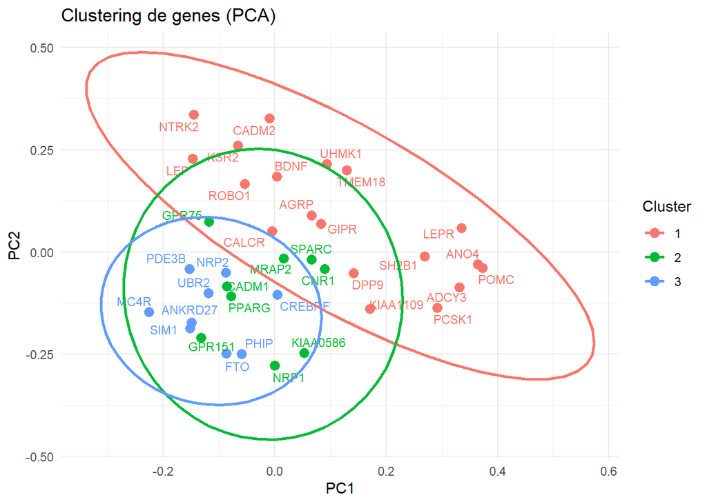

```r
# COORDENADAS DE VARIABLES (GENES) EN EL PCA

coord_genes <- as.data.frame(pca_genes$rotation[, 1:3])

## Añadimos nombre del gen

coord_genes$gene <- rownames(coord_genes)

# CLUSTERING (3 CLUSTERS)

set.seed(123)  # Para reproducibilidad

kmeans_res <- kmeans(coord_genes[, 1:3], centers = 3)

## Añadimos cluster a la tabla

coord_genes$cluster <- as.factor(kmeans_res$cluster)

#  VISUALIZACIÓN

ggplot(coord_genes, aes(x = PC1, y = PC2, color = cluster)) +

  geom_point(size = 3) +

  geom_text_repel(aes(label = gene), size = 3) +

  stat_ellipse(type = "norm", level = 0.95, linewidth = 1) +

  theme_minimal() +

  labs(
    title = "Clustering de genes (PCA)",
    x = "PC1",
    y = "PC2",
    color = "Cluster"
  )
```

## 1.31 AGRUPACIÓN DE INDIVIDUOS POR PCA

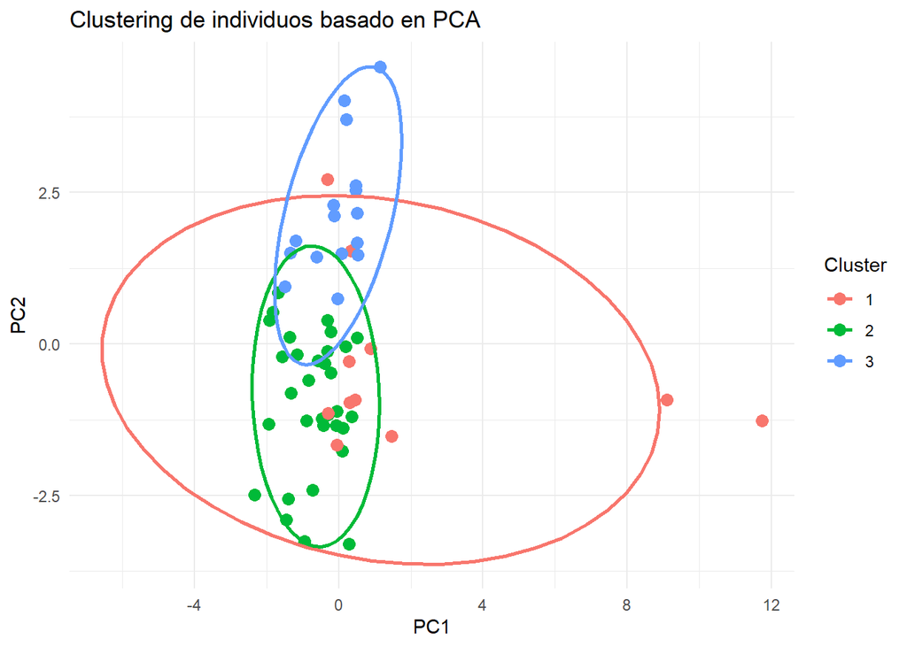

```r
# Ahora vamos a agrupar individuos, no genes

# SCORES DEL PCA (INDIVIDUOS)

# Extraemos los scores de los individuos Simpson

scores_ind <- as.data.frame(pca_genes$x[, 1:3])


#  CLUSTERING DE INDIVIDUOS

# Agrupamos por el método k-means, indicando tres centros (grupos)

set.seed(123)

kmeans_ind <- kmeans(scores_ind, centers = 3)

## Añadimos cluster

scores_ind$cluster <- as.factor(kmeans_ind$cluster)


# VISUALIZACIÓN

ggplot(scores_ind, aes(x = PC1, y = PC2, color = cluster)) +

  geom_point(size = 3) +

  stat_ellipse(level = 0.95, linewidth = 1) +   # Elipses

  theme_minimal() +

  labs(
    title = "Clustering de individuos basado en PCA",
    x = "PC1",
    y = "PC2",
    color = "Cluster"
  )
```

## 1.32 DISTRIBUCIÓN POR IMC EN EL PCA

Se analiza la distribución de los individuos en el espacio del PCA en función de su categoría de índice de masa corporal (IMC), clasificada en normal, sobrepeso y obesidad. Los individuos se representan en el plano PC1–PC2, incorporando coloreado por categoría y elipses de dispersión para evaluar posibles patrones de agrupación. La proximidad entre puntos indica similitud en los perfiles de expresión génica. Si las categorías de IMC aparecen agrupadas, podría sugerir una relación entre la expresión génica y estado nutricional. El resultado permite explorar la posible relación entre los perfiles de expresión génica y el estado ponderal de los individuos.

El agrupamiento de puntos y la superposición de elipses sugiere la ausencia de una clara separación entre los perfiles de expresión génica en función del estado de IMC

No obstante, se observa una mayor dispersión en el grupo de obesidad, incluyendo algunos individuos con valores extremos en el eje PC1, lo que podría indicar la existencia de subgrupos biológicamente diferenciados dentro de esta categoría.

En conjunto, estos resultados sugieren que la variabilidad en los perfiles de expresión génica es más compleja que la clasificación basada en IMC, y podría estar influida por otros factores metabólicos o moleculares no capturados directamente por esta variable.

```r
# CREACIÓN DE VARIABLE IMC CATEGÓRICA

# Se crean categorías clínicas de IMC
simpson_df$IMC_cat <- cut(
  simpson_df$imc_kg_m2,
  breaks = c(-Inf, 24.9, 29.9, Inf),
  labels = c("Normal", "Sobrepeso", "Obesidad")
)

# Se comprueba la distribución de pacientes por categoría
table(simpson_df$IMC_cat)
```

```
##
##    Normal Sobrepeso  Obesidad
##        32        20         7
```

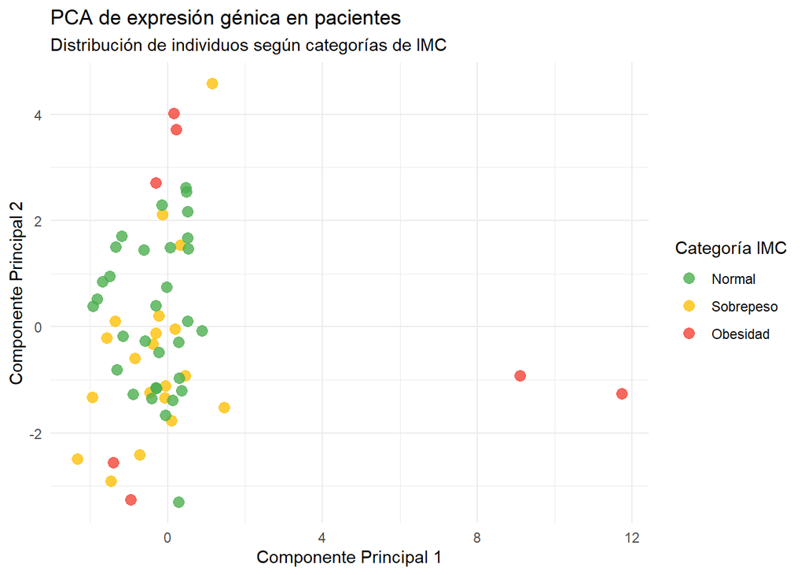

```r
# PREPARACIÓN PARA VISUALIZACIÓN

# Se extraen las coordenadas de los individuos en el PCA
pca_df <- as.data.frame(pca_genes$x)

# Se añaden variables clínicas y de identificación
pca_df$IMC_cat <- simpson_df$IMC_cat
pca_df$nombre <- simpson_df$nombre


# VISUALIZACIÓN DEL PCA SEGÚN IMC

# Se representa el plano formado por PC1 y PC2
# Los individuos se colorean según su categoría de IMC

ggplot(pca_df, aes(x = PC1, y = PC2, color = IMC_cat)) +
  geom_point(size = 3, alpha = 0.8) +
  theme_minimal() +
  labs(
    title = "PCA de expresión génica en pacientes",
    subtitle = "Distribución de individuos según categorías de IMC",
    x = "Componente Principal 1",
    y = "Componente Principal 2",
    color = "Categoría IMC"
  ) +
  scale_color_manual(values = c(
    "Normal" = "#4CAF50",
    "Sobrepeso" = "#FFC107",
    "Obesidad" = "#F44336"
  ))
```

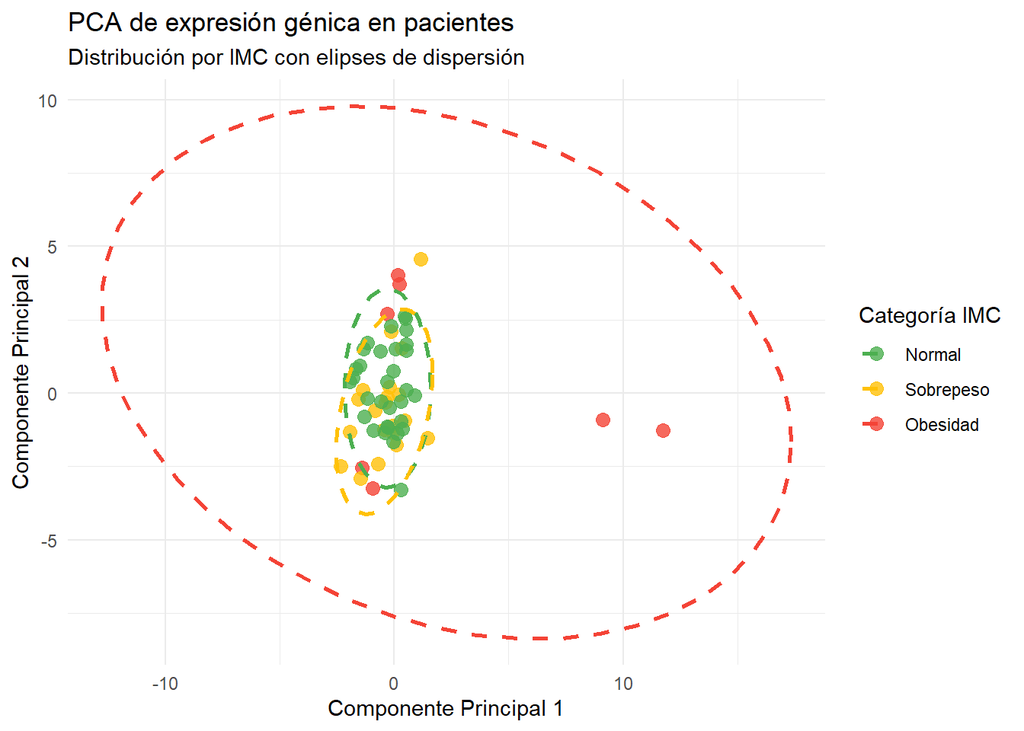

```r
#  VISUALIZACIÓN DEL PCA CON ELIPSES POR IMC

# En este gráfico añadimos elipses para representar la dispersión de cada grupo
# de IMC en el espacio definido por PC1 y PC2 (ayudan a visualizar
# si los grupos están separados o solapados)

ggplot(pca_df, aes(x = PC1, y = PC2, color = IMC_cat)) +

  # Puntos individuales (cada paciente)
  geom_point(size = 3, alpha = 0.8) +

  # Elipses por grupo de IMC
  stat_ellipse(aes(group = IMC_cat), linetype = 2, size = 1) +

  # Tema limpio
  theme_minimal() +

  # Etiquetas
  labs(
    title = "PCA de expresión génica en pacientes",
    subtitle = "Distribución por IMC con elipses de dispersión",
    x = "Componente Principal 1",
    y = "Componente Principal 2",
    color = "Categoría IMC"
  ) +

  # Colores personalizados
  scale_color_manual(values = c(
    "Normal" = "#4CAF50",
    "Sobrepeso" = "#FFC107",
    "Obesidad" = "#F44336"
  ))
```

## 1.33 MODELO DE REGRESIÓN LOGÍSTICA

Se van a construir tres modelos de regresión logística binaria para evaluar la asociación entre los terciles de los componentes principales del PCA y la presencia de sobrepeso (IMC ≥ 25), incorporando progresivamente variables sociodemográficas y clínicas. La bondad global de ajuste de los modelos se evaluará mediante pruebas de razón de verosimilitudes comparando cada modelo con el modelo nulo.

```r
# Variable binaria: sobrepeso (IMC ≥ 25)

simpson_df$sobrepeso <- ifelse(simpson_df$imc_kg_m2 >= 25, 1, 0)

# Unifico datasets

df_modelo <- cbind(
  simpson_df[, c("sobrepeso", "edad_anios", "sexo",
                 "colesterol_total_mg_dl", "glucosa_mg_dl")],
  df_final[, c("PC1_t", "PC2_t", "PC3_t")]
)

# Asegurar que son factores

df_modelo$sexo <- as.factor(df_modelo$sexo)
df_modelo$PC1_t <- as.factor(df_modelo$PC1_t)
df_modelo$PC2_t <- as.factor(df_modelo$PC2_t)
df_modelo$PC3_t <- as.factor(df_modelo$PC3_t)

# Referencias (T1 como referencia)

df_modelo$PC1_t <- relevel(df_modelo$PC1_t, ref = "T1")
df_modelo$PC2_t <- relevel(df_modelo$PC2_t, ref = "T1")
df_modelo$PC3_t <- relevel(df_modelo$PC3_t, ref = "T1")

# Tomar en cuenta también la variable sexo Femenino como referencia

df_modelo$sexo <- relevel(df_modelo$sexo, ref = "Femenino")

# Generar el primer modelo para la regresión (solo PCA)

modelo_1 <- glm(
  sobrepeso ~ PC1_t + PC2_t + PC3_t,
  family = binomial(link = "logit"),
  data = df_modelo
)

summary(modelo_1)
```

```
##
## Call:
## glm(formula = sobrepeso ~ PC1_t + PC2_t + PC3_t, family = binomial(link = "logit"),
##     data = df_modelo)
##
## Coefficients:
##             Estimate Std. Error z value Pr(>|z|)
## (Intercept)  0.07987    0.72474   0.110   0.9122
## PC1_tT2      0.17696    0.69787   0.254   0.7998
## PC1_tT3      0.27195    0.68846   0.395   0.6928
## PC2_tT2     -0.65885    0.69857  -0.943   0.3456
## PC2_tT3     -1.43347    0.71335  -2.009   0.0445 *
## PC3_tT2      0.89625    0.68806   1.303   0.1927
## PC3_tT3     -0.03059    0.70631  -0.043   0.9655
## ---
## Signif. codes:  0 '***' 0.001 '**' 0.01 '*' 0.05 '.' 0.1 ' ' 1
##
## (Dispersion parameter for binomial family taken to be 1)
##
##     Null deviance: 81.367  on 58  degrees of freedom
## Residual deviance: 75.205  on 52  degrees of freedom
## AIC: 89.205
##
## Number of Fisher Scoring iterations: 4
```

```r
# Generar el segundo modelo: sociodemográfico

modelo_2 <- glm(
  sobrepeso ~ PC1_t + PC2_t + PC3_t +
    edad_anios + sexo,
  family = binomial(link = "logit"),
  data = df_modelo
)

# Generar el tercer modelo: incluyendo metabolitos

modelo_3 <- glm(
  sobrepeso ~ PC1_t + PC2_t + PC3_t +
    edad_anios + sexo +
    colesterol_total_mg_dl + glucosa_mg_dl,
  family = binomial(link = "logit"),
  data = df_modelo
)
# Extraer OR, IC95 y p-value

extraer_or <- function(modelo) {

  tidy(modelo, exponentiate = TRUE, conf.int = TRUE) %>%
    mutate(
      OR_IC = paste0(
        round(estimate, 2),
        " (",
        round(conf.low, 2),
        " - ",
        round(conf.high, 2),
        ")"
      ),
      p_value = signif(p.value, 3)
    ) %>%
    select(term, OR_IC, p_value)
}

# Crear tablas individuales de resultados de la regresión

tabla_m1 <- extraer_or(modelo_1)
tabla_m2 <- extraer_or(modelo_2)
tabla_m3 <- extraer_or(modelo_3)
```

[output not shown]

[output cut: 56 more lines]

[output not shown]

```r
# Creo tabla final

tabla_final <- tabla_m1 %>%
  rename(M1_OR = OR_IC, M1_p = p_value) %>%
  full_join(
    tabla_m2 %>% rename(M2_OR = OR_IC, M2_p = p_value),
    by = "term"
  ) %>%
  full_join(
    tabla_m3 %>% rename(M3_OR = OR_IC, M3_p = p_value),
    by = "term"
  )

tabla_final <- tabla_final %>%
  mutate(
    term = case_when(
      grepl("PC1_t", term) ~ "Terciles PC1",
      grepl("PC2_t", term) ~ "Terciles PC2",
      grepl("PC3_t", term) ~ "Terciles PC3",
      grepl("edad", term) ~ "Edad",
      grepl("sexo", term) ~ "Sexo",
      grepl("colesterol", term) ~ "Colesterol total",
      grepl("glucosa", term) ~ "Glucosa",
      TRUE ~ term
    )
  )

write.csv(tabla_final, file ="Tabla Regresion.csv", sep = " ", na = "-", dec = ".")
# Generar modelo nulo y comparación

modelo_nulo <- glm(
  sobrepeso ~ 1,
  data = df_modelo,
  family = binomial(link = "logit")
)

anova(
  modelo_nulo,
  modelo_1,
  test = "Chisq"
)
```

```
## Analysis of Deviance Table
##
## Model 1: sobrepeso ~ 1
## Model 2: sobrepeso ~ PC1_t + PC2_t + PC3_t
##   Resid. Df Resid. Dev Df Deviance Pr(>Chi)
## 1        58     81.367
## 2        52     75.205  6   6.1624   0.4052
```

```r
anova(
  modelo_nulo,
  modelo_2,
  test = "Chisq"
)
```

```
## Analysis of Deviance Table
##
## Model 1: sobrepeso ~ 1
## Model 2: sobrepeso ~ PC1_t + PC2_t + PC3_t + edad_anios + sexo
##   Resid. Df Resid. Dev Df Deviance Pr(>Chi)
## 1        58     81.367
## 2        50     69.535  8   11.832   0.1588
```

```r
anova(
  modelo_nulo,
  modelo_3,
  test = "Chisq"
)
```

```
## Analysis of Deviance Table
##
## Model 1: sobrepeso ~ 1
## Model 2: sobrepeso ~ PC1_t + PC2_t + PC3_t + edad_anios + sexo + colesterol_total_mg_dl +
##     glucosa_mg_dl
##   Resid. Df Resid. Dev Df Deviance Pr(>Chi)
## 1        58     81.367
## 2        48     61.747 10    19.62  0.03306 *
## ---
## Signif. codes:  0 '***' 0.001 '**' 0.01 '*' 0.05 '.' 0.1 ' ' 1
```

## 1.34 *Interpretación de la regresión logística*

### 1.34.1 Modelo 1: asociación cruda (PCA sin ajuste)

El primer modelo incluyó únicamente los terciles de los tres primeros componentes principales.

Comparación con modelo nulo:

La comparación global con el modelo nulo no mostró mejora significativa:

χ² = 6.16 gl = 6 p = 0.405

El modelo no mejora significativamente respecto a un modelo sin predictores.

### 1.34.2 Modelo 2: ajuste sociodemográfico

Se incluyeron edad y sexo además de los componentes principales.

Las variables sociodemográficas tampoco mostraron asociación significativa con el sobrepeso en este modelo.

Edad: OR = 1.02 (IC95%: 0.98–1.07), p = 0.340 Sexo masculino: OR = 1.24 (IC95%: 0.18–8.33), p = 0.828

Comparación con modelo nulo:

χ² = 11.83 gl = 8 p = 0.159

Mejora parcial del modelo, pero sin significación estadística global.

### 1.34.3 Modelo 3: ajuste clínico completo

El modelo final incluyó, además de los componentes PCA, edad, sexo, colesterol total y glucosa.

En este modelo:

Los componentes del PCA no mostraron asociación significativa con sobrepeso.

La glucosa mostró asociación significativa positiva:

```
Glucosa: OR = 1.21 (IC95%: 1.01–1.45), p = 0.037
```

El colesterol total mostró una tendencia inversa no significativa:

```
OR = 0.95 (IC95%: 0.90–1.01), p = 0.106
```

Comparación con modelo nulo:

El modelo completo mostró una mejora significativa respecto al modelo nulo:

χ² = 19.62 gl = 10 p = 0.033*

El modelo completo aporta información estadísticamente significativa para explicar el sobrepeso.

### 1.34.4 Conclusión global

El ajuste progresivo mejora la capacidad explicativa del modelo. El modelo completo es estadísticamente significativo frente al modelo nulo. La variable glucosa aparece como el principal factor asociado positivamente con el sobrepeso.

Esto sugiere que, aunque la estructura global de expresión génica resumida por PCA no discrimina el sobrepeso, ciertos marcadores metabólicos individuales pueden tener mayor relevancia explicativa.

## 1.35 CONCLUSIONES

En este estudio se ha realizado un análisis integral de la expresión génica combinando técnicas descriptivas, PCA y métodos de agrupación. El PCA ha permitido identificar los principales patrones de variabilidad, mientras que la estratificación por terciles y el clustering han evidenciado la existencia de perfiles diferenciados de individuos y genes. La incorporación de variables clínicas, como el IMC, ha facilitado la exploración de posibles relaciones entre expresión génica y características fenotípicas. En conjunto, los resultados muestran el potencial de estas herramientas para el análisis exploratorio y la generación de hipótesis en estudios bioestadísticos.

En conjunto, los resultados indican que el IMC no captura completamente la diversidad biológica subyacente en los perfiles de expresión génica, evidenciando la complejidad del sistema metabólico Simpson.